# CS236781: Deep Learning on Computational Accelerators

# Homework Assignment 4

Faculty of Computer Science, Technion.

Submitted by:

| # | Name | Id | email |
| --- | --- | --- | --- |
| Student 1 | Moshe Kimhi | 203374293 | moshekimhi@campus.technion.ac.il |
| Student 2 | Shai Kimhi | 318605516 | shai.kimhi@campus.technion.ac.il |

## Introduction

In this assignment we'll explore deep reinforcement learning. We'll implement two popular and related methods for directly learning the policy of an agent for playing a simple video game.

## General Guidelines

- Please read the [getting started page](https://vistalab-technion.github.io/cs236781/assignments/getting-started) on the course website. It explains how to **setup, run and submit** the assignment.
- This assignment requires running on GPU-enabled hardware. Please read the [course servers usage guide](https://vistalab-technion.github.io/cs236781/assignments/hpc-servers). It explains how to use and run your code on the course servers to benefit from training with GPUs.
- The text and code cells in these notebooks are intended to guide you through the assignment and help you verify your solutions. The notebooks **do not need to be edited** at all (unless explicitly specified). The only exception is to fill your name(s) in the above cell before submission. Please do not remove sections or change the order of any cells.
- All your code (and even answers to questions) should be written in the files within the python package corresponding the assignment number (`hw1`, `hw2`, etc). You can of course use any editor or IDE to work on these files.

## Contents

- Part1: Deep Reinforcement Learning
  - Policy Gradients
  - Advantage Actor-Critic (AAC)
  - Questions
- Part2: Summary Questions
- Part3: Mini-Project

$$ \newcommand{\mat}[1]{\boldsymbol {#1}} \newcommand{\mattr}[1]{\boldsymbol {#1}^\top} \newcommand{\matinv}[1]{\boldsymbol {#1}^{-1}} \newcommand{\vec}[1]{\boldsymbol {#1}} \newcommand{\vectr}[1]{\boldsymbol {#1}^\top} \newcommand{\rvar}[1]{\mathrm {#1}} \newcommand{\rvec}[1]{\boldsymbol{\mathrm{#1}}} \newcommand{\diag}{\mathop{\mathrm {diag}}} \newcommand{\set}[1]{\mathbb {#1}} \newcommand{\cset}[1]{\mathcal{#1}} \newcommand{\norm}[1]{\left\lVert#1\right\rVert} \newcommand{\pderiv}[2]{\frac{\partial #1}{\partial #2}} \newcommand{\bb}[1]{\boldsymbol{#1}} \newcommand{\E}[2][]{\mathbb{E}_{#1}\left[#2\right]} \newcommand{\ip}[3]{\left<#1,#2\right>_{#3}} \newcommand{\given}[]{\,\middle\vert\,} \newcommand{\DKL}[2]{\cset{D}_{\text{KL}}\left(#1\,\Vert\, #2\right)} \newcommand{\grad}[]{\nabla} $$

# Part 1: Deep Reinforcement Learning

In the tutorial we have seen value-based reinforcement learning, in which we learn to approximate the action-value function $q(s,a)$.

In this exercise we'll explore a different approach, directly learning the agent's policy distribution, $\pi(a|s)$ by using *policy gradients*, in order to safely land on the moon!

```python
%load_ext autoreload
%autoreload 2
%matplotlib inline

import unittest
import os
import sys
import pathlib
import urllib
import shutil
import re

import numpy as np
import torch
import torch.nn as nn
import torch.optim as optim
import matplotlib.pyplot as plt
```

```python
test = unittest.TestCase()
plt.rcParams.update({'font.size': 12})
device = torch.device('cuda' if torch.cuda.is_available() else 'cpu')

# Prefer CPU, GPU won't help much in this assignment
device = 'cpu'
print('Using device:', device)

# Seed for deterministic tests
SEED = 42
```

```
Using device: cpu
```

Some technical notes before we begin:

- This part does not require a GPU. We won't need large models, and the computation bottleneck will be the generation of episodes to train on.
- In order to run this notebook on the server, you must prepend the `xvfb-run` command to create a virtual screen. For example,
  - to run this notebook with `srun` do

    ```
      srun -c2 --gres=gpu:1 xvfb-run -a -s "-screen 0 1440x900x24" python main.py run-nb <filename>
    ```

  - To run the submission script, do

    ```
      srun -c2 xvfb-run -a -s "-screen 0 1440x900x24" python main.py prepare-submission ...
    ```

  - note that we have already included the `xvfb-run` command inside the `jupyter-lab.sh` script, so you can use it as usual with `srun`. and so on.
- The OpenAI `gym` library is not officially supported on windows. However it should be possible to install and run the necessary environment for this exercise. However, we cannot provide you with technical support for this. If you have trouble installing locally, we suggest running on the course server.

## Policy gradients

Recall from the tutorial that we define the **policy** of an agent as the conditional distribution, $$ \pi(a|s) = \Pr(a_t=a\vert s_t=s), $$ which defines how likely the agent is to take action $a$ at state $s$.

Furthermore we define the action-value function, $$ q_{\pi}(s,a) = \E{g_t(\tau)|s_t = s,a_t=a,\pi} $$ where $$ g_t(\tau) = r_{t+1}+\gamma r_{t+2} + \dots = \sum_{k=0}^{\infty} \gamma^k r_{t+1+k}, $$ is the total discounted reward of a specific trajectory $\tau$ from time $t$, and the expectation in $q$ is over all possible trajectories, $ \tau=\left\{ (s_0,a_0,r_1,s_1), \dots (s_T,a_T,r_{T+1},s_{T+1}) \right\}. $

In the tutorial we saw that we can learn a value function starting with some random function and updating it iteratively by using the **Bellman optimality equation**. Given that we have some action-value function, we can immediately create a policy based on that by simply selecting an action which maximize the action-value at the current state, i.e. $$ \pi(a|s) = \begin{cases} 1, & a = \arg\max_{a'\in\cset{A}} q(s,a') \\ 0, & \text{else} \end{cases}. $$ This is called $q$-learning. This approach aims to obtain a policy indirectly through the action-value function. Yet, in most cases we don't actually care about knowing the value of particular states, since all we need is a good policy for our agent.

Here we'll take a different approach and learn a policy distribution $\pi(a|s)$ directly - by using **policy gradients**.

### Formalism

We define a parametric policy, $\pi_\vec{\theta}(a|s)$, and maximize total discounted reward (or minimize the negative reward): $$ \mathcal{L}(\vec{\theta})=\E[\tau]{-g(\tau)|\pi_\vec{\theta}} = -\int g(\tau)p(\tau|\vec{\theta})d\tau, $$ where $p(\tau|\vec{\theta})$ is the probability of a specific trajectory $\tau$ under the policy defined by $\vec{\theta}$.

Since we want to find the parameters $\vec{\theta}$ which minimize $\mathcal{L}(\vec{\theta})$, we'll compute the gradient w.r.t. $\vec{\theta}$: $$ \grad\mathcal{L}(\vec{\theta}) = -\int g(\tau)\grad p(\tau|\vec{\theta})d\tau. $$

Unfortunately, if we try to write $p(\tau|\vec{\theta})$ explicitly, we find that computing it's gradient with respect to $\vec{\theta}$ is quite intractable due to a huge product of terms depending on $\vec{\theta}$: $$ p(\tau|\vec{\theta})=p\left(\left\{ (s_t,a_t,r_{t+1},s_{t+1})\right\}_{t\geq0}\given\vec{\theta}\right) =p(s_0)\prod_{t\geq0} \pi_{\vec{\theta}}(a_t|s_t)p(s_{t+1}|s_t,a_t). $$

However, by using the fact that $\grad_{x}\log(f(x))=\frac{\grad_{x}f(x)}{f(x)}$, we can convert the product into a sum: $$ \begin{align} \grad\mathcal{L}(\vec{\theta}) &= -\int g(\tau)\grad p(\tau|\vec{\theta})d\tau = -\int g(\tau)\frac{\grad p(\tau|\vec{\theta})}{p(\tau|\vec{\theta})}p(\tau|\vec{\theta})d\tau \\ &= -\int g(\tau)\grad\log\left(p(\tau|\vec{\theta})\right)p(\tau|\vec{\theta})d\tau \\ &= -\int g(\tau)\grad\log\left( p(s_0)\prod_{t\geq0} \pi_{\vec{\theta}}(a_t|s_t)p(s_{t+1}|s_t,a_t) \right) p(\tau|\vec{\theta})d\tau \\ &= -\int g(\tau)\grad\left( \log p(s_0) + \sum_{t\geq0} \log \pi_{\vec{\theta}}(a_t|s_t) + \sum_{t\geq0}\log p(s_{t+1}|s_t,a_t) \right) p(\tau|\vec{\theta})d\tau \\ &= -\int g(\tau)\sum_{t\geq0} \grad\log \pi_{\vec{\theta}}(a_t|s_t) p(\tau|\vec{\theta})d\tau \\ &= \E[\tau]{-g(\tau)\sum_{t\geq0} \grad\log \pi_{\vec{\theta}}(a_t|s_t)}. \end{align} $$

This is the "vanilla" version of the policy gradient. We can interpret is as a weighted log-likelihood function. The log-policy is the log-likelihood term we wish to maximize and the total discounted reward acts as a weight: high-return positive trajectories will cause the probability of actions taken during them to increase, and negative-return trajectories will cause the probabilities of actions taken to decrease.

The major drawback of the policy-gradient is it's high variance, which causes erratic optimization behavior and therefore slow convergence. One reason for this is that the log-policy weight term, $g(\tau)$ can vary wildly between different trajectories, even if they're similar in actions. Later on we'll implement the loss and explore some methods of variance reduction.

### Landing on the moon with policy gradients

In the spirit of the recent achievements of the Israeli space industry, we'll apply our reinforcement learning skills to solve a simple game called **LunarLander**.

This game is available as an `environment` in OpenAI `gym`.

[video not shown]

In this environment, you need to control the lander and get it to land safely on the moon. To do so, you must apply bottom, right or left thrusters (each are either fully on or fully off) and get it to land within the designated zone as quickly as possible and with minimal wasted fuel.

```python
import gym

# Just for fun :) ... but also to re-define the default max number of steps
ENV_NAME = 'Beresheet-v2'
MAX_EPISODE_STEPS = 300
if ENV_NAME not in gym.envs.registry.env_specs:
    gym.register(
        id=ENV_NAME,
        entry_point='gym.envs.box2d:LunarLander',
        max_episode_steps=MAX_EPISODE_STEPS,
        reward_threshold=200,
    )
```

```python
import gym

env = gym.make(ENV_NAME)

print(env)
print(f'observations space: {env.observation_space}')
print(f'action space: {env.action_space}')

ENV_N_ACTIONS = env.action_space.n
ENV_N_OBSERVATIONS = env.observation_space.shape[0]
```

```
<TimeLimit<LunarLander<Beresheet-v2>>>
observations space: Box(-inf, inf, (8,), float32)
action space: Discrete(4)
```

The observations at each step is the Lander's position, velocity, angle, angular velocity and ground contact state. The actions are no-op, fire left truster, bottom thruster and right thruster.

You are **highly encouraged** to read the [documentation](https://github.com/openai/gym/blob/master/gym/envs/box2d/lunar_lander.py) in the source code of the `LunarLander` environment to understand the reward system, and see how the actions and observations are created.

### Policy network and Agent

Let's start with our policy-model. This will be a simple neural net, which should take an observation and return a score for each possible action.

**TODO**:

1. Implement all methods in the `PolicyNet` class in the `hw4/rl_pg.py` module. Start small. A simple MLP with a few hidden layers is a good starting point. You can come back and change it later based on the the experiments.  
   Notice that we'll use the `build_for_env` method to instantiate a `PolicyNet` based on the configuration of a given environment.
2. If you need hyperparameters to configure your model (e.g. number of hidden layers, sizes, etc.), add them in `part1_pg_hyperparams()` in `hw4/answers.py`.

```python
import hw4.rl_pg as hw4pg
import hw4.answers

hp = hw4.answers.part1_pg_hyperparams()

# You can add keyword-args to this function which will be populated from the
# hyperparameters dict.
p_net = hw4pg.PolicyNet.build_for_env(env, device, **hp)
p_net
```

```
PolicyNet(
  (model): Sequential(
    (0): Linear(in_features=8, out_features=32, bias=True)
    (1): PReLU(num_parameters=1)
    (2): Linear(in_features=32, out_features=32, bias=True)
    (3): PReLU(num_parameters=1)
    (4): Linear(in_features=32, out_features=4, bias=True)
  )
)
```

Now we need an **agent**. The purpose of our agent will be to act according to the current policy and generate experiences. Our `PolicyAgent` will use a `PolicyNet` as the current policy function.

We'll also define some extra datatypes to help us represent the data generated by our agent. You can find the `Experience`, `Episode` and `TrainBatch` datatypes in the `hw4/rl_data.py` module.

**TODO**: Implement the `current_action_distribution()` method of the `PolicyAgent` class in the `hw4/rl_pg.py` module.

```python
for i in range (10):
    agent = hw4pg.PolicyAgent(env, p_net, device)
    d = agent.current_action_distribution()

    test.assertSequenceEqual(d.shape, (env.action_space.n,))
    test.assertAlmostEqual(d.sum(), 1.0, delta=1e-5)

print(d)
```

```
tensor([0.2589, 0.2839, 0.2314, 0.2258])
```

**TODO**: Implement the `step()` method of the `PolicyAgent`.

```python
agent = hw4pg.PolicyAgent(env, p_net, device)
exp = agent.step()

test.assertIsInstance(exp, hw4pg.Experience)
print(exp)
```

```
Experience(state=tensor([ 0.0066,  1.4000,  0.6683, -0.4856, -0.0076, -0.1514,  0.0000,  0.0000]), action=0, reward=-1.0632516431372494, is_done=False)
```

To test our agent, we'll write some code that allows it to play an environment. We'll use the `Monitor` wrapper in `gym` to generate a video of the episode for visual debugging.

**TODO**: Complete the implementation of the `monitor_episode()` method of the `PolicyAgent`.

```python
env, n_steps, reward = agent.monitor_episode(ENV_NAME, p_net, device=device)
```

To display the Monitor video in this notebook, we'll use a helper function from our `jupyter_utils` and a small wrapper that extracts the path of the last video file.

```python
import cs236781.jupyter_utils as jupyter_utils

def show_monitor_video(monitor_env, idx=0, **kw):
    # Extract video path
    video_path = monitor_env.videos[idx][0]
    video_path = os.path.relpath(video_path, start=os.path.curdir)

    # Use helper function to embed the video
    return jupyter_utils.show_video_in_notebook(video_path, **kw)
```

```python
print(f'Episode ran for {n_steps} steps. Total reward: {reward:.2f}')

show_monitor_video(env)
```

```
Episode ran for 78 steps. Total reward: -265.10
```

[video not shown]

### Training data

The next step is to create data to train on. We need to train on batches of state-action pairs, so that our network can learn to predict the actions.

We'll split this task into three parts:

1. Generate a batch of `Episode`s, by using an `Agent` that's playing according to our current policy network. Each `Episode` object contains the `Experience` objects created by the agent.
2. Calculate the total discounted reward for each state we encountered and action we took. This is our action-value estimate.
3. Convert the `Episode`s into a batch of tensors to train on. Each batch will contain states, action taken per state, reward accrued, and the calculated estimated state-values. These will be stored in a `TrainBatch` object.

**TODO**: Complete the implementation of the `episode_batch_generator()` method in the `TrainBatchDataset` class within the `hw4.rl_data` module. This will address part 1 in the list above.

```python
import hw4.rl_data as hw4data

def agent_fn():
    env = gym.make(ENV_NAME)
    hp = hw4.answers.part1_pg_hyperparams()
    p_net = hw4pg.PolicyNet.build_for_env(env, device, **hp)
    return hw4pg.PolicyAgent(env, p_net, device)

ds = hw4data.TrainBatchDataset(agent_fn, episode_batch_size=8, gamma=0.9)
batch_gen = ds.episode_batch_generator()
b = next(batch_gen)
print('First episode:', b[0])

test.assertEqual(len(b), 8)
for ep in b:
    test.assertIsInstance(ep, hw4data.Episode)

    # Check that it's a full episode
    is_done = [exp.is_done for exp in ep.experiences]
    test.assertFalse(any(is_done[0:-1]))
    test.assertTrue(is_done[-1])
```

```
First episode: Episode(total_reward=-119.16, #experences=95)
```

**TODO**: Complete the implementation of the `calc_qvals()` method in the `Episode` class. This will address part 2. These q-values are an estimate of the actual action value function: $$\hat{q}_{t} = \sum_{t'\geq t} \gamma^{t'-t}r_{t'+1}.$$

```python
np.random.seed(SEED)
test_rewards = np.random.randint(-10, 10, 100)
test_experiences = [hw4pg.Experience(None,None,r,False) for r in test_rewards]
test_episode = hw4data.Episode(np.sum(test_rewards), test_experiences)

qvals = test_episode.calc_qvals(0.9)
qvals = list(qvals)

expected_qvals = np.load(os.path.join('tests', 'assets', 'part1_expected_qvals.npy'))
for i in range(len(test_rewards)):
    test.assertAlmostEqual(expected_qvals[i], qvals[i], delta=1e-3)
```

**TODO**: Complete the implementation of the `from_episodes()` method in the `TrainBatch` class. This will address part 3.

Notes:

- The `TrainBatchDataset` class provides a generator function that will use the above function to lazily generate batches of training samples and labels on demand.
- This allows us to use a standard `PyTorch` dataloader to wrap our Dataset and provide us with parallel data loading for free! This means we can run multiple environments with multiple agents in separate background processes to generate data for training and thus prevent the data loading bottleneck which is caused by the fact that we must generate full Episodes to train on in order to calculate the q-values.
- We'll set the `DataLoader`'s `batch_size` to `None` because we have already implemented custom batching in our dataset.
- You can choose the number of worker processes generating data using the `num_workers` parameter in the hyperparams dict. Set `num_workers=0` to disable parallelization.

```python
from torch.utils.data import DataLoader

hp = hw4.answers.part1_pg_hyperparams()

ds = hw4data.TrainBatchDataset(agent_fn, episode_batch_size=8, gamma=0.9)
dl = DataLoader(
    ds,
    batch_size=None,
    num_workers=hp['num_workers'],
    multiprocessing_context='fork' if hp['num_workers'] > 0 else None
)


for i, train_batch in enumerate(dl):
    states, actions, qvals, reward_mean = train_batch
    print(f'#{i}: {train_batch}')
    test.assertEqual(states.shape[0], actions.shape[0])
    test.assertEqual(qvals.shape[0], actions.shape[0])
    test.assertEqual(states.shape[1], env.observation_space.shape[0])
    if i > 5:
        break
```

```
#0: TrainBatch(states: torch.Size([777, 8]), actions: torch.Size([777]), q_vals: torch.Size([777])), num_episodes: 8)
#1: TrainBatch(states: torch.Size([715, 8]), actions: torch.Size([715]), q_vals: torch.Size([715])), num_episodes: 8)
#2: TrainBatch(states: torch.Size([862, 8]), actions: torch.Size([862]), q_vals: torch.Size([862])), num_episodes: 8)
#3: TrainBatch(states: torch.Size([799, 8]), actions: torch.Size([799]), q_vals: torch.Size([799])), num_episodes: 8)
#4: TrainBatch(states: torch.Size([790, 8]), actions: torch.Size([790]), q_vals: torch.Size([790])), num_episodes: 8)
#5: TrainBatch(states: torch.Size([871, 8]), actions: torch.Size([871]), q_vals: torch.Size([871])), num_episodes: 8)
#6: TrainBatch(states: torch.Size([808, 8]), actions: torch.Size([808]), q_vals: torch.Size([808])), num_episodes: 8)
```

### Loss functions

As usual, we need a loss function to optimize over. We'll calculate three types of losses:

1. The causal vanilla policy gradient loss.
2. The policy gradient loss, with a baseline to reduce variance.
3. An entropy-based loss whos purpose is to diversify the agent's action selection, and prevent it from being "too sure" about its actions. This loss will be used together with one of the above losses.

#### Causal vanilla policy-gradient

We have derived the policy-gradient as $$ \grad\mathcal{L}(\vec{\theta}) = \E[\tau]{-g(\tau)\sum_{t\geq0} \grad\log \pi_{\vec{\theta}}(a_t|s_t)}. $$

By writing the discounted reward explicitly and enforcing causality, i.e. the action taken at time $t$ can't affect the reward at time $t'<t$, we can get a slightly lower-variance version of the policy gradient:

$$ \grad\mathcal{L}_{\text{PG}}(\vec{\theta}) = \E[\tau]{-\sum_{t\geq0} \left(\sum_{t'\geq t} \gamma^{t'-t}r_{t'+1} \right)\grad\log \pi_{\vec{\theta}}(a_t|s_t)}. $$

In practice, the expectation over trajectories is calculated using a Monte-Carlo approach, i.e. simply sampling $N$ trajectories and average the term inside the expectation. Therefore, we will use the following estimated version of the policy gradient:

$$ \begin{align} \hat\grad\mathcal{L}_{\text{PG}}(\vec{\theta}) &=-\frac{1}{N}\sum_{i=1}^{N}\sum_{t\geq0} \left(\sum_{t'\geq t} \gamma^{t'-t}r_{i,t'+1} \right)\grad\log \pi_{\vec{\theta}}(a_{i,t}|s_{i,t}) \\ &=-\frac{1}{N}\sum_{i=1}^{N}\sum_{t\geq0} \hat{q}_{i,t} \grad\log \pi_{\vec{\theta}}(a_{i,t}|s_{i,t}). \end{align} $$

Note the use of the notation $\hat{q}_{i,t}$ to represent the estimated action-value at time $t$ in the sampled trajectory $i$. Here $\hat{q}_{i,t}$ is acting as the weight-term for the policy gradient.

**TODO**: Complete the implementation of the `VanillaPolicyGradientLoss` class in the `hw4/rl_pg.py` module.

```python
# Ensure deterministic run
env = gym.make(ENV_NAME)
env.seed(SEED)
torch.manual_seed(SEED)

def agent_fn():
    # Use a simple "network" here, so that this test doesn't depend on
    # your specific PolicyNet implementation
    p_net_test = nn.Linear(ENV_N_OBSERVATIONS, ENV_N_ACTIONS, bias=True)
    agent = hw4pg.PolicyAgent(env, p_net_test)
    return agent

dataloader = hw4data.TrainBatchDataset(agent_fn, gamma=0.9, episode_batch_size=4)

test_batch = next(iter(dataloader))
test_action_scores = torch.randn(len(test_batch), env.action_space.n)
print(f"{test_batch=}", end='\n\n')
print(f"test_action_scores=\n{test_action_scores}\nshape={test_action_scores.shape}", end='\n\n')

loss_fn_p = hw4pg.VanillaPolicyGradientLoss()
loss_p, _ = loss_fn_p(test_batch, test_action_scores)

print(f'{loss_p=}')
test.assertAlmostEqual(loss_p.item(), -36.642, delta=1e-2)
```

```
test_batch=TrainBatch(states: torch.Size([388, 8]), actions: torch.Size([388]), q_vals: torch.Size([388])), num_episodes: 4)

test_action_scores=
tensor([[-7.8158e-01, -1.5094e-01,  4.1993e-01,  1.4059e+00],
        [ 1.3185e+00,  2.8492e-05,  1.4242e+00, -6.2004e-01],
        [ 1.1881e+00,  2.0556e+00,  6.6027e-01, -1.1078e+00],
        ...,
        [-3.4807e-01, -9.6609e-01, -6.5453e-01, -2.0421e+00],
        [-1.1453e+00,  8.8890e-01,  2.4767e-01,  9.7610e-01],
        [-1.2878e+00,  1.9194e+00, -9.3162e-01, -3.8786e-01]])
shape=torch.Size([388, 4])

loss_p=tensor(-36.6422)
```

#### Policy-gradient with baseline

Another way to reduce the variance of our gradient is to use relative weighting of the log-policy instead of absolute reward values. $$ \hat\grad\mathcal{L}_{\text{BPG}}(\vec{\theta}) =-\frac{1}{N}\sum_{i=1}^{N}\sum_{t\geq0} \left(\hat{q}_{i,t}-b\right) \grad\log \pi_{\vec{\theta}}(a_{i,t}|s_{i,t}). $$ In other words, we don't measure a trajectory's worth by it's total reward, but by how much better that total reward is relative to some expected ("baseline") reward value, denoted above by $b$. Note that subtracting a baseline has no effect on the expected value of the policy gradient. It's easy to prove this directly by definition.

Here we'll implement a very simple baseline (not optimal in terms of variance reduction): the average of the estimated state-values $\hat{q}_{i,t}$.

**TODO**: Complete the implementation of the `BaselinePolicyGradientLoss` class in the `hw4/rl_pg.py` module.

```python
# Using the same batch and action_scores from above cell
loss_fn_p = hw4pg.BaselinePolicyGradientLoss()
loss_p, loss_dict = loss_fn_p(test_batch, test_action_scores)

print(f'{loss_dict=}')
test.assertAlmostEqual(loss_dict['baseline'], -22.191, delta=1e-2)
test.assertAlmostEqual(loss_p.item(), -0.278, delta=1e-2)
```

```
loss_dict={'loss_p': -0.2786746621131897, 'baseline': -22.191144943237305}
```

#### Entropy loss

The entropy of a probability distribution (in our case the policy), is $$ H(\pi) = -\sum_{a} \pi(a|s)\log\pi(a|s). $$ The entropy is always positive and obtains it's maximum for a uniform distribution. We'll use the entropy of the policy as a bonus, i.e. we'll try to maximize it. The idea is the prevent the policy distribution from becoming too narrow and thus promote the agent's exploration.

First, we'll calculate the maximal possible entropy value of the action distribution for a set number of possible actions. This will be used as a normalization term.

**TODO**: Complete the implementation of the `calc_max_entropy()` method in the `ActionEntropyLoss` class.

```python
loss_fn_e = hw4pg.ActionEntropyLoss(env.action_space.n)
print('max_entropy = ', loss_fn_e.max_entropy)

test.assertAlmostEqual(loss_fn_e.max_entropy, 1.38629436, delta=1e-3)
```

```
max_entropy =  1.3862943611198906
```

**TODO**: Complete the implementation of the `forward()` method in the `ActionEntropyLoss` class.

```python
loss_e, _ = loss_fn_e(test_batch, test_action_scores)
print('loss = ', loss_e)

test.assertAlmostEqual(loss_e.item(), -0.8103, delta=1e-2)
```

```
loss =  tensor(-0.8103)
```

### Training

We'll implement our training procedure as follows:

1. Initialize the current policy to be a random policy.
2. Sample $N$ trajectories from the environment using the current policy.
3. Calculate the estimated $q$-values, $\hat{q}_{i,t} = \sum_{t'\geq t} \gamma^{t'}r_{i,t'+1}$ for each trajectory $i$.
4. Calculate policy gradient estimate $\hat\grad\mathcal{L}(\vec{\theta})$ as defined above.
5. Perform SGD update $\vec{\theta}\leftarrow\vec{\theta}-\eta\hat\grad\mathcal{L}(\vec{\theta})$.
6. Repeat from step 2.

This is known as the **REINFORCE** algorithm.

Fortunately, we've already implemented everything we need for steps 1-4 so we need only a bit more code to put it all together.

The following block implements a wrapper, `train_pg` to create all the objects we need in order to train our policy gradient model.

```python
import hw4.answers
from functools import partial

ENV_NAME = "Beresheet-v2"

def agent_fn_train(agent_type, p_net, seed, envs_dict):
    winfo = torch.utils.data.get_worker_info()
    wid = winfo.id if winfo else 0
    seed = seed + wid if seed else wid

    env = gym.make(ENV_NAME)
    envs_dict[wid] = env
    env.seed(seed)
    np.random.seed(seed)
    torch.manual_seed(seed)

    return agent_type(env, p_net)

def train_rl(agent_type, net_type, loss_fns, hp, seed=None, checkpoints_file=None, **train_kw):
    print(f'hyperparams: {hp}')

    envs = {}
    p_net = net_type(ENV_N_OBSERVATIONS, ENV_N_ACTIONS, **hp)
    p_net.share_memory()
    agent_fn = partial(agent_fn_train, agent_type, p_net, seed, envs)

    dataset = hw4data.TrainBatchDataset(agent_fn, hp['batch_size'], hp['gamma'])
    dataloader = DataLoader(
        dataset, batch_size=None, num_workers=hp['num_workers'],
        multiprocessing_context='fork' if hp['num_workers'] > 0 else None
    )
    optimizer = optim.Adam(p_net.parameters(), lr=hp['learn_rate'], eps=hp['eps'])

    trainer = hw4pg.PolicyTrainer(p_net, optimizer, loss_fns, dataloader, checkpoints_file)
    try:
        trainer.train(**train_kw)
    except KeyboardInterrupt as e:
        print('Training interrupted by user.')
    finally:
        for env in envs.values():
            env.close()

    # Include final model state
    training_data = trainer.training_data
    training_data['model_state'] = p_net.state_dict()
    return training_data

def train_pg(baseline=False, entropy=False, **train_kwargs):
    hp = hw4.answers.part1_pg_hyperparams()

    loss_fns = []
    if baseline:
        loss_fns.append(hw4pg.BaselinePolicyGradientLoss())
    else:
        loss_fns.append(hw4pg.VanillaPolicyGradientLoss())
    if entropy:
        loss_fns.append(hw4pg.ActionEntropyLoss(ENV_N_ACTIONS, hp['beta']))

    return train_rl(hw4pg.PolicyAgent, hw4pg.PolicyNet, loss_fns, hp, **train_kwargs)
```

The `PolicyTrainer` class implements the training loop, collects the losses and rewards and provides some useful checkpointing functionality. The training loop will generate batches of episodes and train on them until either:

- The average total reward from the last `running_mean_len` episodes is greater than the `target_reward`, OR
- The number of generated episodes reached `max_episodes`.

Most of this class is already implemented for you.

**TODO**:

1. Complete the training loop by implementing the `train_batch()` method of the `PolicyTrainer`.
2. Tweak the hyperparameters in the `part1_pg_hyperparams()` function within the `hw4/answers.py` module as needed. You get some sane defaults.

Let's check whether our model is actually training. We'll try to reach a very low (bad) target reward, just as a sanity check to see that training works. Your model should be able to reach this target reward within a few batches.

You can increase the target reward and use this block to manually tweak your model and hyperparameters a few times.

```python
target_reward = -140 # VERY LOW target
train_data = train_pg(target_reward=target_reward, seed=SEED, max_episodes=2000, running_mean_len=10)

test.assertGreater(train_data['mean_reward'][-1], target_reward)
```

```
hyperparams: {'batch_size': 64, 'gamma': 0.99, 'beta': 0.5, 'learn_rate': 0.005, 'eps': 2e-08, 'num_workers': 2}
=== Training...
#3: step=00023549, loss_p=-147.93, m_reward(10)=-127.2 (best=-156.8):  13%|█▎        | 256/2000 [00:11<01:17, 22.45it/s]

=== 🚀 SOLVED - Target reward reached! 🚀
```

### Experimenting with different losses

We'll now run a few experiments to see the effect of diferent loss functions on the training dynamics. Namely, we'll try:

1. Vanilla PG (`vpg`): No baseline, no entropy
2. Baseline PG (`bpg`): Baseline, no entropy loss
3. Entropy PG (`epg`): No baseline, with entropy loss
4. Combined PG (`cpg`): Baseline, with entropy loss

```python
from collections import namedtuple
from pprint import pprint
import itertools as it


ExpConfig = namedtuple('ExpConfig', ('name','baseline','entropy'))

def exp_configs():
    exp_names = ('vpg', 'epg', 'bpg', 'cpg')
    z = zip(exp_names, it.product((False, True), (False, True)))
    return (ExpConfig(n, b, e) for (n, (b, e)) in z)

pprint(list(exp_configs()))
```

```
[ExpConfig(name='vpg', baseline=False, entropy=False),
 ExpConfig(name='epg', baseline=False, entropy=True),
 ExpConfig(name='bpg', baseline=True, entropy=False),
 ExpConfig(name='cpg', baseline=True, entropy=True)]
```

We'll save the training data from each experiment for plotting.

```python
import pickle

def dump_training_data(data, filename):
    os.makedirs(os.path.dirname(filename), exist_ok=True)
    with open(filename, mode='wb') as file:
        pickle.dump(data, file)

def load_training_data(filename):
    with open(filename, mode='rb') as file:
        return pickle.load(file)
```

Let's run the experiments! We'll run each configuration for a fixed number of episodes so that we can compare them.

Notes:

1. Until your models start working, you can decrease the number of episodes for each experiment, or only run one experiment.
2. The results will be saved in a file. To re-run the experiments, you can set `force_run` to `True`.

```python
import math

exp_max_episodes = 4000

results = {}
training_data_filename = os.path.join('results', f'part1_exp.dat')

# Set to True to force re-run (careful! will delete old experiment results)
force_run = False

# Skip running if results file exists.
if os.path.isfile(training_data_filename) and not force_run:
    print(f'=== results file {training_data_filename} exists, skipping experiments.')
    results = load_training_data(training_data_filename)

else:
    for n, b, e in exp_configs():
        print(f'=== Experiment {n}')
        results[n] = train_pg(baseline=b, entropy=e, max_episodes=exp_max_episodes, post_batch_fn=None)

    dump_training_data(results, training_data_filename)
```

```
=== results file results/part1_exp.dat exists, skipping experiments.
```

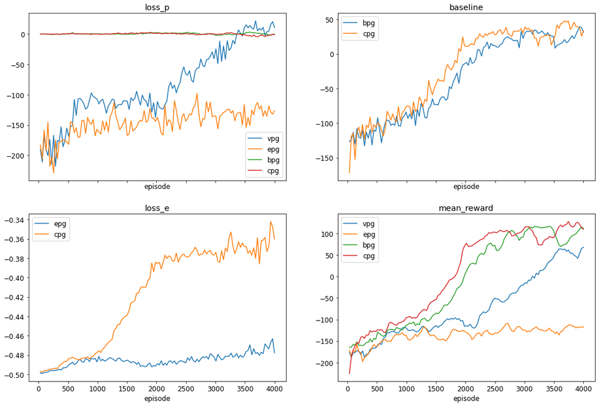

```python
def plot_experiment_results(results, fig=None):
    if fig is None:
        fig, _ = plt.subplots(nrows=2, ncols=2, sharex=True, figsize=(18,12))
    for i, plot_type in enumerate(('loss_p', 'baseline', 'loss_e', 'mean_reward')):
        ax = fig.axes[i]
        for exp_name, exp_res in results.items():
            if plot_type not in exp_res:
                continue
            ax.plot(exp_res['episode_num'], exp_res[plot_type], label=exp_name)
        ax.set_title(plot_type)
        ax.set_xlabel('episode')
        ax.legend()
    return fig

experiments_results_fig = plot_experiment_results(results)
```

You should see positive training dynamics in the graphs (reward going up). If you don't, use them to further update your model or hyperparams.

To pass the test, you'll need to get a best total mean reward of at least 10 in the fixed number of epochs using the combined loss. It's possible to get much higher (over 100).

```python
best_cpg_mean_reward = max(results['cpg']['mean_reward'])
print(f'Best CPG mean reward: {best_cpg_mean_reward:.2f}')

test.assertGreater(best_cpg_mean_reward, 10)
```

```
Best CPG mean reward: 127.63
```

Now let's take a look at a gameplay video of our `cpg` model after the short training!

```python
hp = hw4.answers.part1_pg_hyperparams()
p_net_cpg = hw4pg.PolicyNet.build_for_env(env, **hp)
p_net_cpg.load_state_dict(results['cpg']['model_state'])

env, n_steps, reward = hw4pg.PolicyAgent.monitor_episode(ENV_NAME, p_net_cpg)
print(f'{n_steps} steps, total reward: {reward:.2f}')
show_monitor_video(env)
```

```
300 steps, total reward: 213.49
```

[video not shown]

## Advantage Actor-Critic (AAC)

We have seen that the policy-gradient loss can be interpreted as a log-likelihood of the policy term (selecting a specific action at a specific state), weighted by the future rewards of that choice of action.

However, naïvely weighting by rewards has significant drawbacks in terms of the variance of the resulting gradient. We addressed this by adding a simple baseline term which represented our "expected reward" so that we increase probability of actions leading to trajectories which exceed this expectation and vice-versa.

In this part we'll explore a more powerful baseline, which is the idea behind the AAC method.

### The advantage function

Recall the definition of the state-value function $v_{\pi}(s)$ and action-value function $q_{\pi}(s,a)$:

$$ \begin{align} v_{\pi}(s) &= \E{g(\tau)|s_0 = s,\pi} \\ q_{\pi}(s,a) &= \E{g(\tau)|s_0 = s,a_0=a,\pi}. \end{align} $$

Both these functions represent the value of the state $s$. However, $v_\pi$ averages over the first action according to the policy, while $q_\pi$ fixes the first action and then continues according to the policy.

Their difference is known as the **advantage function**: $$ a_\pi(s,a) = q_\pi(s,a)-v_\pi(s). $$

If $a_\pi(s,a)>0$ it means that it's better (in expectation) to take action $a$ in state $s$ compared to the average action. In other words, $a_\pi(s,a)$ represents the *advantage* of using action $a$ in state $s$ compared to the others.

So far we have used an estimate for $q_\pi$ as our weighting term for the log-policy, with a fixed baseline per batch.

$$ \hat\grad\mathcal{L}_{\text{BPG}}(\vec{\theta}) =-\frac{1}{N}\sum_{i=1}^{N}\sum_{t\geq0} \left(\hat{q}_{i,t}-b\right) \grad\log \pi_{\vec{\theta}}(a_{i,t}|s_{i,t}). $$

Now, we will use the state value as a baseline, so that an estimate of the advantage function is our weighting term:

$$ \hat\grad\mathcal{L}_{\text{AAC}}(\vec{\theta}) =-\frac{1}{N}\sum_{i=1}^{N}\sum_{t\geq0} \left(\hat{q}_{i,t}-v_\pi(s_t)\right) \grad\log \pi_{\vec{\theta}}(a_{i,t}|s_{i,t}). $$

Intuitively, using the advantage function makes sense because it means we're weighting our policy's actions according to how advantageous they are compared to other possible actions.

But how will we know $v_\pi(s)$? We'll learn it of course, using another neural network. This is known as actor-critic learning. We simultaneously learn the policy (actor) and the value of states (critic). We'll treat it as a regression task: given a state $s_t$, our state-value network will output $\hat{v}_\pi(s_t)$, an estimate of the actual unknown state-value. Our regression targets will be the discounted rewards, $\hat{q}_{i,t}$ (see question 2), and we can use a simple MSE as the loss function, $$ \mathcal{L}_{\text{SV}} = \frac{1}{N}\sum_{i=1}^{N}\sum_{t\geq0}\left(\hat{v}_\pi(s_t) - \hat{q}_{i,t}\right)^2. $$

### Implementation

We'll build heavily on our implementation of the regular policy-gradient method, and just add a new model class and a new loss class, with a small modification to the agent.

Let's start with the model. It will accept a state, and return action scores (as before), but also the value of that state. You can experiment with a dual-head network that has a shared base, or implement two separate parts within the network.

**TODO**:

1. Implement the model as the `AACPolicyNet` class in the `hw4/rl_ac.py` module.
2. Set the hyperparameters in the `part1_aac_hyperparams()` function of the `hw4.answers` module.

```python
import hw4.rl_ac as hw4ac

hp = hw4.answers.part1_aac_hyperparams()
pv_net = hw4ac.AACPolicyNet.build_for_env(env, device, **hp)
pv_net
```

```
AACPolicyNet(
  (shared): Sequential(
    (0): Linear(in_features=8, out_features=32, bias=True)
    (1): PReLU(num_parameters=1)
    (2): Linear(in_features=32, out_features=16, bias=True)
    (3): PReLU(num_parameters=1)
    (4): Linear(in_features=16, out_features=16, bias=True)
    (5): PReLU(num_parameters=1)
  )
  (policy_model): Sequential(
    (0): Linear(in_features=16, out_features=4, bias=True)
  )
  (value_model): Sequential(
    (0): Dropout(p=0.4, inplace=False)
    (1): Linear(in_features=16, out_features=1, bias=True)
  )
)
```

**TODO**: Complete the implementation of the agent class, `AACPolicyAgent`, in the `hw4/rl_ac.py` module.

```python
agent = hw4ac.AACPolicyAgent(env, pv_net, device)
exp = agent.step()

test.assertIsInstance(exp, hw4pg.Experience)
print(exp)
```

```
Experience(state=tensor([ 0.0074,  1.4019,  0.7521, -0.4005, -0.0086, -0.1704,  0.0000,  0.0000]), action=3, reward=-2.2963478045490135, is_done=False)
```

**TODO**: Implement the AAC loss function as the class `AACPolicyGradientLoss` in the `hw4/rl_ac.py` module.

```python
loss_fn_aac = hw4ac.AACPolicyGradientLoss(delta=1.)
test_state_values = torch.ones(test_action_scores.shape[0], 1)
loss_t, loss_dict = loss_fn_aac(test_batch, (test_action_scores, test_state_values))

print(f'{loss_dict=}')
test.assertAlmostEqual(loss_dict['adv_m'], -23.191, delta=1e-2)
test.assertAlmostEqual(loss_t.item(), 1183.948, delta=1e-2)
```

```
loss_dict={'loss_p': -38.28092956542969, 'loss_v': 1222.228759765625, 'adv_m': -23.191171646118164}
```

### Experimentation

Let's run the same experiment as before, but with the AAC method and compare the results.

```python
def train_aac(baseline=False, entropy=False, **train_kwargs):
    hp = hw4.answers.part1_aac_hyperparams()
    loss_fns = [hw4ac.AACPolicyGradientLoss(hp['delta']), hw4pg.ActionEntropyLoss(ENV_N_ACTIONS, hp['beta'])]
    return train_rl(hw4ac.AACPolicyAgent, hw4ac.AACPolicyNet, loss_fns, hp, **train_kwargs)
```

```python
training_data_filename = os.path.join('results', f'part1_exp_aac.dat')

# Set to True to force re-run (careful, will delete old experiment results)
force_run = False

if os.path.isfile(training_data_filename) and not force_run:
    print(f'=== results file {training_data_filename} exists, skipping experiments.')
    results_aac = load_training_data(training_data_filename)

else:
    print(f'=== Running AAC experiment')
    training_data = train_aac(max_episodes=exp_max_episodes)
    results_aac = dict(aac=training_data)
    dump_training_data(results_aac, training_data_filename)
```

```
=== results file results/part1_exp_aac.dat exists, skipping experiments.
```

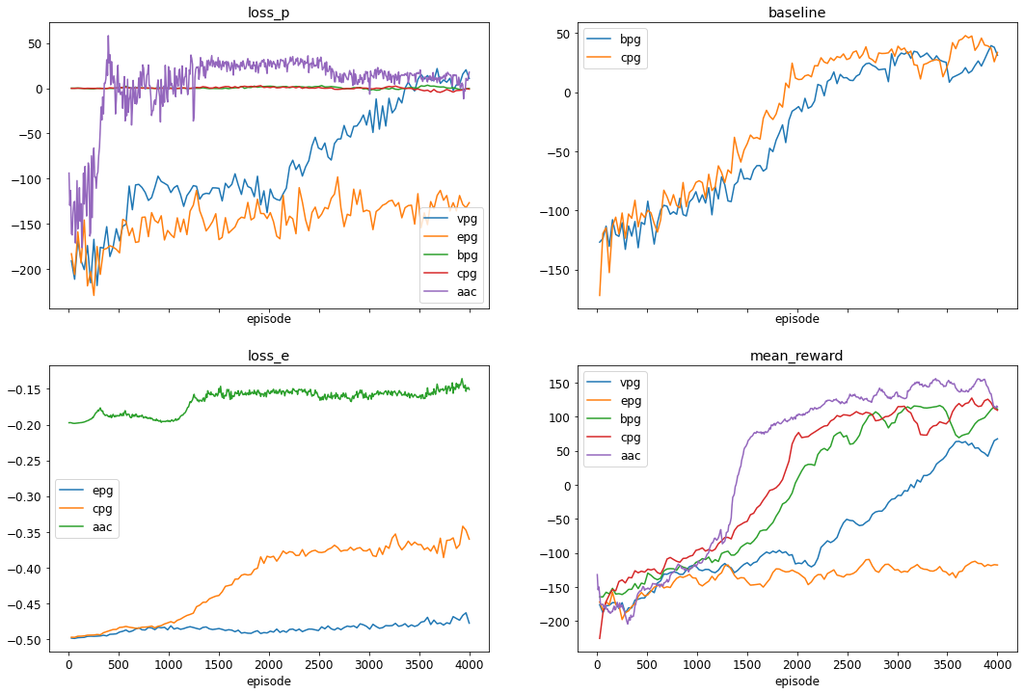

```python
experiments_results_fig = plot_experiment_results(results)
plot_experiment_results(results_aac, fig=experiments_results_fig);
```

You should get better results with the AAC method, so this time the bar is higher (again, you should aim for a mean reward of 100+). Compare the graphs with combined PG method and see if they make sense.

```python
best_aac_mean_reward = max(results_aac['aac']['mean_reward'])
print(f'Best AAC mean reward: {best_aac_mean_reward:.2f}')

test.assertGreater(best_aac_mean_reward, 50)
```

```
Best AAC mean reward: 156.17
```

### Final model training and visualization

Now, using your best model and hyperparams, let's train model for much longer and see the performance. Just for fun, we'll also visualize an episode every now and then so that we can see how well the agent is playing.

- Run the following block to train.
- Tweak model or hyperparams as necessary.
- Aim for high mean reward, at least 150+. It's possible to get over 200.
- When training is done and you're satisfied with the model's outputs, rename the checkpoint file by adding `_final` to the file name. This will cause the block to skip training and instead load your saved model when running the homework submission script. Note that your submission zip file will not include the checkpoint file. This is OK.

```python
import IPython.display

CHECKPOINTS_FILE = f'checkpoints/{ENV_NAME}-ac.dat'
CHECKPOINTS_FILE_FINAL = f'checkpoints/{ENV_NAME}-ac.dat'
TARGET_REWARD = 125
MAX_EPISODES = 15_000

def post_batch_fn(batch_idx, p_net, batch, print_every=20, final=False):
    if not final and batch_idx % print_every != 0:
        return
    env, n_steps, reward = hw4ac.AACPolicyAgent.monitor_episode(ENV_NAME, p_net)
    html = show_monitor_video(env, width="500")
    IPython.display.clear_output(wait=True)
    print(f'Monitor@#{batch_idx}: n_steps={n_steps}, total_reward={reward:.3f}, final={final}')
    IPython.display.display_html(html)


if os.path.isfile(CHECKPOINTS_FILE_FINAL):
    print(f'=== {CHECKPOINTS_FILE_FINAL} exists, skipping training...')
    checkpoint_data = torch.load(CHECKPOINTS_FILE_FINAL)
    hp = hw4.answers.part1_aac_hyperparams()
    pv_net = hw4ac.AACPolicyNet.build_for_env(env, **hp)
    pv_net.load_state_dict(checkpoint_data['params'])
    print(f'=== Running best model...')
    env, n_steps, reward = hw4ac.AACPolicyAgent.monitor_episode(ENV_NAME, pv_net)
    print(f'=== Best model ran for {n_steps} steps. Total reward: {reward:.2f}')
    IPython.display.display_html(show_monitor_video(env))
    best_mean_reward = checkpoint_data["best_mean_reward"]
else:
    print(f'=== Starting training...')
    train_data = train_aac(TARGET_REWARD, max_episodes=MAX_EPISODES,
                           seed=None, checkpoints_file=CHECKPOINTS_FILE, post_batch_fn=post_batch_fn)
    print(f'=== Done, ', end='')
    best_mean_reward = train_data["best_mean_reward"][-1]
    print(f'num_episodes={train_data["episode_num"][-1]}, best_mean_reward={best_mean_reward:.1f}')

test.assertGreaterEqual(best_mean_reward, TARGET_REWARD)
```

```
=== checkpoints/Beresheet-v2-ac.dat exists, skipping training...
=== Running best model...
=== Best model ran for 300 steps. Total reward: 209.47
```

[video not shown]

## Questions

**TODO**: Answer the following questions. Write your answers in the appropriate variables in the module `hw4/answers.py`.

```python
from cs236781.answers import display_answer
import hw4.answers
```

### Question 1

Explain qualitatively why subtracting a baseline in the policy-gradient helps reduce it's variance. Specifically, give an example where it helps.

```python
display_answer(hw4.answers.part1_q1)
```

The baseline is simply the mean of the predicted q values, as an empicical expectation of the q value, that help to reduce variance. If we look at the reward as a function $R(t)$ this function is not continues with time (there is a huge diffrance between sparse reawrds and dense rewards but it's not the scope of the answer). The point is as such: when the agent play a trajectory with a high reward, the gradients will be very small as oppose to other trajectories. when we substract the expected q values, we would reduce this effect (the variance between trajectories). The idea of a baseline can also help us determine a higher baseline and try to help the model update the parameters even if in general the reward is positive (as in the launar lander example).

### Question 2

In AAC, when using the estimated q-values as regression targets for our state-values, why do we get a valid approximation? Hint: how is $v_\pi(s)$ expressed in terms of $q_\pi(s,a)$?

```python
display_answer(hw4.answers.part1_q2)
```

$ v_{\pi}(s) = \sum_{a \in \mathcal{A}(s)} \pi(a|s_t=s) \cdot \tilde{q}_{\pi}(s,a) $.

Recall that under policy $\pi$:

$$ \begin{align} v_{\pi}(s) &= \mathbb{E}[g_t(\tau))|s_t=s, \pi] \\ q_{\pi}(s,a) &= \mathbb{E}[g_t(\tau)|s_t=s, a_t = a, \pi] \end{align} $$

the relation between $v_{\pi}(s)$ and $q_{\pi}(s,a)$ can be presented as:
$$ \begin{align} v_{\pi}(s) &= \mathbb{E}[g_t(\tau)|s_t=s, \pi] \\ &= \sum_{a \in \mathcal{A}(s)} \pi(a|s_t=s) \mathbb{E}[g_t(\tau)|s_t=s, a_t = a, \pi] \\ &= \sum_{a \in \mathcal{A}(s)} \pi(a|s_t=s) \cdot q_{\pi}(s,a) \end{align} $$

and the estimation relay on that relation.

### Question 3

1. Analyze and explain the graphs you got in first experiment run.
2. Compare the experiment graphs you got with the AAC method to the regular PG method (`cpg`).

```python
display_answer(hw4.answers.part1_q3)
```

1. First experiment: Result analysis

   - The graph loss\_e shows the entropy loss as the negative entropy. The values rise as the networks learns with subsequent iterations. High entropy values imply that the action probability distribution resembles a uniform distribution, whereas a reduction in entropy marks the network's converges on the effective policy; the network is more confident of the proper actions.  
     The subtraction of baseline $b$ in $\hat\grad\mathcal{L}_{\text{CPG}}(\vec{\theta})$ `cpg` speeds up the rate of convergence (in comparison to $\hat\grad\mathcal{L}_{\mathcal{H}(\pi)}(\vec{\theta})$ `epg`) thus making the training process more efficient.

1. Comparison between Regular Policy-Gradient `cpg` and Advantage Actor-Critic `AAC`

   - The graph loss\_e illustrates the entropy loss of `AAC` and `cpg` .  
     The two methods perform similarly - up to a scale factor determined by the ratio of entropy loss multipliers $~{}^{\mathbb{\beta}_{\text{CPG}}~~}{\mskip -5mu/\mskip -3mu}_{~~\mathbb{\beta}_{\text{AAC}}}$.

$$ \newcommand{\mat}[1]{\boldsymbol {#1}} \newcommand{\mattr}[1]{\boldsymbol {#1}^\top} \newcommand{\matinv}[1]{\boldsymbol {#1}^{-1}} \newcommand{\vec}[1]{\boldsymbol {#1}} \newcommand{\vectr}[1]{\boldsymbol {#1}^\top} \newcommand{\rvar}[1]{\mathrm {#1}} \newcommand{\rvec}[1]{\boldsymbol{\mathrm{#1}}} \newcommand{\diag}{\mathop{\mathrm {diag}}} \newcommand{\set}[1]{\mathbb {#1}} \newcommand{\cset}[1]{\mathcal{#1}} \newcommand{\norm}[1]{\left\lVert#1\right\rVert} \newcommand{\pderiv}[2]{\frac{\partial #1}{\partial #2}} \newcommand{\bb}[1]{\boldsymbol{#1}} \newcommand{\E}[2][]{\mathbb{E}_{#1}\left[#2\right]} \newcommand{\ip}[3]{\left<#1,#2\right>_{#3}} \newcommand{\given}[]{\,\middle\vert\,} \newcommand{\DKL}[2]{\cset{D}_{\text{KL}}\left(#1\,\Vert\, #2\right)} \newcommand{\grad}[]{\nabla} \newcommand{\norm}[1]{\left\lVert#1\right\rVert} $$

# Part 2: Summary Questions

This section contains summary questions about various topics from the course material.

You can add your answers in new cells below the questions.

**Notes**

- Clearly mark where your answer begins, e.g. write "**Answer:**" in the beginning of your cell.
- Provide a full explanation, even if the question doesn't explicitly state so. We will reduce points for partial explanations!
- This notebook should be runnable from start to end without any errors.

### CNNs

1. Explain the meaning of the term "receptive field" in the context of CNNs.

**Answer:** "receptive field" is the name for the size of the input that the kernel "see" and can produce a feature out of. The most important meaning is when we use a CNN, the conv component extract features, and we want to be able to extract the most important features for the given problem (in general images we want to be scale invariant and so we want the end of the CNN to have a large receptive field).

1. Explain and elaborate about three different ways to control the rate at which the receptive field grows from layer to layer. Compare them to each other in terms of how they combine input features.

**Answer:** There are several ways to increase the receptive field, we will talk about **kernel size**, **stride**, and **dilated convulution**. (note that the easiest way to control the R.F is to add layers, but the question ask about the growth from layer to layer)

$RF_L = RF_{L-1} + (F_L -1) \times S $ where L denote a layer,F the kernel size and S denote stride. (the real formula of r.f is $RF_L = RF_{L-1} + (F_L -1)\cdot \prod_{l=1}^{i-1} S_l$ but the effect of stride is enogh on one layer for this answer).

1. kernel size: we can see from the eq. above that bigger kernel size provide bigger receptive field. this is the most intuitive, since we simply see more pixels.
2. stride: assuming we pad same, stride denotes the 'step' size we do while convolve. *for example for 1 layer with ker_size 3x3 and stride 2: the first multiplication would see prev_layer[0:2][0:2], then prev_layer[2:4][0:2], then prev_layer[4:6][0:2], then prev_layer[0:2][2:4] and so on... in total the receptive field would be 7x7*
3. dilated convulution: this notion simply make a 'gap' (or add zeros) between the kernel parameters. for kernel_size 3x3 and dilation=2, we would get a kernel of 9 parameters, but the receptive field would be the same like we used kernel of 5x5.
1. Imagine a CNN with three convolutional layers, defined as follows:

```python
import torch
import torch.nn as nn

cnn = nn.Sequential(
    nn.Conv2d(in_channels=3, out_channels=4, kernel_size=3, padding=1),
    nn.ReLU(),
    nn.MaxPool2d(2),
    nn.Conv2d(in_channels=4, out_channels=16, kernel_size=5, stride=2, padding=2),
    nn.ReLU(),
    nn.MaxPool2d(2),
    nn.Conv2d(in_channels=16, out_channels=32, kernel_size=7, dilation=2, padding=3),
    nn.ReLU(),
)

cnn(torch.rand(size=(1, 3, 1024, 1024), dtype=torch.float32)).shape
```

```
torch.Size([1, 32, 122, 122])
```

What is the size (spatial extent) of the receptive field of each "pixel" in the output tensor?

**Answer:** as we shown in the equation above and for dialution $rf_{d\_i} = d\cdot (f_i-1) + 1 $

$rf_1 = 3$  
$rf_2 = 3 + 1\cdot1 = 4$  
$rf_3 = 4 + 4\cdot2 = 12$  
$rf_4 = 12 + 1\cdot(2\cdot2) = 16$  
$rf_5 = 16 + 12\cdot8 = 112$

so final receptive field is `112x112`

1. You have trained a CNN, where each layer $l$ is represented by the mapping $\vec{y}_l=f_l(\vec{x};\vec{\theta}_l)$, and $f_l(\cdot;\vec{\theta}_l)$ is a convolutional layer (not including the activation function).

   After hearing that residual networks can be made much deeper, you decide to change each layer in your network you used the following residual mapping instead $\vec{y}_l=f_l(\vec{x};\vec{\theta}_l)+\vec{x}$, and re-train.

   However, to your surprise, by visualizing the learned filters $\vec{\theta}_l$ you observe that the original network and the residual network produce completely different filters. Explain the reason for this.

**Answer:** The reason is, that a residual layer and conv layer need to learn diffrent functions, since the input is diffrent. The network could have the exect same preformance with diffrent filters because of that reason. let's use an example: We have a network that learned all the featurse needed by layer i, and the network dept is i+1. the i+1 layer would need to learn the idendity funtion. while for regular convolution the filter would be close to $f_{i+1}(\vec{x};\vec{\theta}_l) = \vec{I}$ and $\vec{y}_i = \vec{x} f_{i+1} =\vec{x} \vec{I} = \vec{x}$, the residual have the input x, so it would need to learn $f_{i+1}(\vec{x};\vec{\theta}_l) = \vec{0}$ and $\vec{y}_i+1 = \vec{x} f_{i+1} + \vec{x} =\vec{x} \vec{0} +\vec{x} = \vec{x}$.

### Dropout

1. Consider the following neural network:

```python
import torch.nn as nn

p1, p2 = 0.1, 0.2
nn.Sequential(
    nn.Conv2d(in_channels=3, out_channels=4, kernel_size=3, padding=1),
    nn.ReLU(),
    nn.Dropout(p=p1),
    nn.Dropout(p=p2),
)
```

If we want to replace the two consecutive dropout layers with a single one defined as follows:

```
nn.Dropout(p=q)
```

what would the value of `q` need to be? Write an expression for `q` in terms of `p1` and `p2`.

**answer**: the probability of neuron to drop afer one layer of dropout is `p1` ,so we have `(1-p1)` left and then we apply another dropout with `p2`, then we stay with `(1-p1)(1-p2)` that is `1+p1p2 -p1 -p2` and q is the probability to drop (we calculated 1-q), means `q = p1+p2 - p1p2`

1. **True or false**: dropout must be placed only after the activation function. **answer**: False: there is no logical effect on using dropout before activisions, but activision function work on all the input, so the library implementation would save some computation time if we use if after the activision
1. After applying dropout with a drop-probability of $p$, the activations are scaled by $1/(1-p)$. Prove that this scaling is required in order to maintain the value of each activation unchanged in expectation.

**answer**: recalls for expectation $E(x) = p(x) x$

let's look at the neurons as a vector $\vec{X}$ with probability 1 to pass forward and $E=X$. When we use dropout of $p$,the probability to choose x is (1-p) and $E(X) = (1-p)X$. the activision expect the same expectation, so we use $1/(1-p) E(X) = (1-p)X/(1-p) = X$

### Losses and Activation functions

1. You're training a an image classifier that, given an image, needs to classify it as either a dog (output 0) or a hotdog (output 1). Would you train this model with an L2 loss? if so, why? if not, demonstrate with a numerical example. What would you use instead?

**answer**: L2 is not commonly use for classifications, while we can teoretically use it for binary classification, it won't be wise. $L2 = \frac{1}{n}\sum_n (y_i - \hat y_i^p)^2$. the main problem with using it is, we take into considiration only the final prediction but not the "score" (probability- the softmax output) of the prediction and there will be no notion of ceirtenty in the classification. while L2 valuse would be 1 or 0, other score, like BCE (Binary Cross Entropy) would consider probability of classification into consideration: $CE =- \frac{1}{n}\sum_n y log(p(\hat{y})) + (1-y)log(1-p(\hat{y})))$

example: for one image of a dog and classification score of p(dog)=0.51 and p(hotdog)=0.49, $L2 = 0$ and $CE = -log(0.51) = 0.29$. we know of course, that a model that think of a dog and hotdog so close, need to be optimized some more. the L2 optimizer model look at the example the same way as in other example of p(dog)=1 and p(hotdog)=0.

1. After months of research into the origins of climate change, you observe the following result:

[figure not shown]

You decide to train a cutting-edge deep neural network regression model, that will predict the global temperature based on the population of pirates in `N` locations around the globe. You define your model as follows:

```python
import torch.nn as nn

N = 42  # number of known global pirate hot spots
H = 128
mlpirate = nn.Sequential(
    nn.Linear(in_features=N, out_features=H),
    nn.Sigmoid(),
    *[
        nn.Linear(in_features=H, out_features=H), nn.Sigmoid(),
    ]*24,
    nn.Linear(in_features=H, out_features=1),
)
```

While training your model you notice that the loss reaches a plateau after only a few iterations. It seems that your model is no longer training. What is the most likely cause?

**Answer**: it's look like the prediction of the global average temperture as a function of the number of pirates is a simple function. the suggested mlpirate model is very large and severely suffer from severely vanishing gradients and if not, very likely overfitting.

1. Referring to question 2 above: A friend suggests that if you replace the `sigmoid` activations with `tanh`, it will solve your problem. Is he correct? Explain why or why not. **Answer**: `tanh` behave like a linear function for low values of $x$, the main reason to use it is to avoid exploding gradients problem, so we don't belive this is the right fit for the given problem
1. Regarding the ReLU activation, state whether the following sentences are **true or false** and explain:
   1. In a model using exclusively ReLU activations, there can be no vanishing gradients.
   2. The gradient of ReLU is linear with its input when the input is positive.
   3. ReLU can cause "dead" neurons, i.e. activations that remain at a constant value of zero.

**Answer**:

```
A. false: ReLU small values in input behave as small values in output, it's in common use for the fast gradients calculation and simplicity.
B. false: the function is liniar with positive input, the gradient is constant.
C. ture in a way*: it is true that for a given layer with negative output the neuron would not recive gradient update, since the gradient for negative input of ReLu is 0, but not teoretically, we train on a lot of data and to be a "dead" neuron, the same one should get negative values for all samples (even in the batched G.D, we need all the data to produce negative output for the input of the ReLU). this can be, but negative values do not get to be more negative since there are no gradients, so in summery, teoretically true.
```

### Optimization

1. Explain the difference between: stochastic gradient descent (SGD), mini-batch SGD and regular gradient descent (GD).

**Answer:**  
Regular Gradient Descent is an optimization algorithm calculating the gradient of the loss over a given dataset,  
while Stochastic Gradient Descent samples one example at each iteration and calculates the gradient of the loss for that one example.  
Mini-batch SGD can be viewed as a mix between SGD and regular GD as it it a method in which a fixed batch of examples is independently sampled from the dataset, and the gradient of the loss is calculated over this fixed-size batch.

1. Regarding SGD and GD:
   1. Provide at least two reasons for why SGD is used more often in practice compared to GD.
   2. In what cases can GD not be used at all?

**Answer:**  
A. The first reason SGD is more often used in practice than GD is that many datasets are extremely large, and thus it is impractical to calculate the gradient over all of the dataset at once as it will both take a lot of time and take a lot of memory. The second reason is that many times sampling different examples from the dataset independently might help to optimize better, it will generate a noisier gradient and that will help the optimization process escape local minima.

B. Regular Gradient Descent can not be used at all when the dataset is so large that the storage requirements of the algorithm are not avaliable.

1. You have trained a deep resnet to obtain SoTA results on ImageNet. While training using mini-batch SGD with a batch size of $B$, you noticed that your model converged to a loss value of $l_0$ within $n$ iterations (batches across all epochs) on average. Thanks to your amazing results, you secure funding for a new high-powered server with GPUs containing twice the amount of RAM. You're now considering to increase the mini-batch size from $B$ to $2B$. Would you expect the number of of iterations required to converge to $l_0$ to decrease or increase when using the new batch size? explain in detail.

**TODO:RECHECK THIS ANSWER!!!!**

**Answer:**  
We would expect the number of iterations required to converge to ${l_0}$ to decrease as using batch size B, we would train over B examples in each iteration, in n iterations we trained our model over ${n\times B}$ samples, increasing the batch size to 2B would allow us to train over twice as many examples and thus, would allow our model function to be approximately more similiar to the optimal function of the classifier, thus we would expect our optimization to converge faster to loss ${l_0}$.

1. For each of the following statements, state whether they're **true or false** and explain why.
   1. When training a neural network with SGD, every epoch we perform an optimization step for each sample in our dataset.
   2. Gradients obtained with SGD have less variance and lead to quicker convergence compared to GD.
   3. SGD is less likely to get stuck in local minima, compared to GD.
   4. Training with SGD requires more memory than with GD.
   5. Assuming appropriate learning rates, SGD is guaranteed to converge to a local minimum, while GD is guaranteed to converge to the global minimum.
   6. Given a loss surface with a narrow ravine (high curvature in one direction): SGD with momentum will converge more quickly than Newton's method which doesn't have momentum.

1. In tutorial 5 we saw an example of bi-level optimization in the context of deep learning, by embedding an optimization problem as a layer in the network. **True or false**: In order to train such a network, the inner optimization problem must be solved with a descent based method (such as SGD, LBFGS, etc). Provide a mathematical justification for your answer.

**Answer:**  
**False**: In order for the outer problem to be solved (i.e training the network), the inner problem must be solvable either through a descent based algorithm or through other methods (could be exact analytical solution).  
Example: for the network we used in the tutorial, we will select ${f(y;z)=||Ay-z||_2^2}$. Thus, ${\hat{y}=argmin_yf(y;z)=(A^tA)^{-1}A^tz}$ is the solution of Least Squares problem. Thus the inner problem can be solved analytically and not throught descent based algorithm

[figure not shown]

1. You have trained a neural network, where each layer $l$ is represented by the mapping $\vec{y}_l=f_l(\vec{x};\vec{\theta}_l)$ for some arbitrary parametrized functions $f_l(\cdot;\vec{\theta}_l)$. Unfortunately while trying to break the record for the world's deepest network, you discover that you are unable to train your network with more than $L$ layers.
   1. Explain the concepts of "vanishing gradients", and "exploding gradients".
   2. How can each of these problems be caused by increased depth?
   3. Provide a numerical example demonstrating each.
   4. Assuming your problem is either of these, how can you tell which of them it is without looking at the gradient tensor(s)?

**Answer:**  
A. Vanishing gradient is a situation in which during a gradient based optimization of a neural network, the calculated gradient of the network is very small. Since gradient based optimization updates the model proportionally to the gradient of the model, the vanishing gradients create a problem which halts the optimization of the model through very small gradient.  
Exploding gradient is a situation in which the the gradient of the network is extermely large, thus the optimization of the model through gradient descent based algorithms could have a difficulty converging because of the large gradient.  
B. The gradient of a neural network is calculated through the chain rule, and thus a deep network could lead to vanishing gradient if the partial derivative of a large number of layers has a spactral norm smaller than 1, if all of the layers satisfy this condition we are guaranteed to have vanishing gradients for a feedforward network and a large enough number of layers, if the spactral norm of the partial derivative of all the layers is greater than 1 we may encounter exploding gradients.  
C. We will take an example of an RNN, and calculate gradient of the loss at time t over the parameters of the model at time i (t > i),

### ${\frac{\delta l_t}{\delta\Theta_i} = \frac{\delta l_t}{\delta y_t}\frac{\delta y_t }{\delta h_t}\frac{\delta h_t }{\delta h_i }\frac{\delta^+ h_i}{\delta \Theta_i} = \frac{\delta l_t}{\delta y_t}\frac{\delta y_t }{\delta h_t}\frac{\delta h_t }{\delta h_{t-1} }...\frac{\delta h_{i+1}}{\delta h_i}\frac{\delta^+ h_i}{\delta \Theta_i} ,\text{ } \frac{\delta y_t }{\delta h_t} = W_{hy}^t, \text{ }\frac{\delta h_t }{\delta h_{t-1}}=W_{hh}^t \Phi'(z_t)}$

Thus,

### ${\frac{\delta y_t }{\delta h_t}\frac{\delta h_t }{\delta h_i }\frac{\delta^+ h_i}{\delta \Theta_i} = W_{hy}^tW_{hh}^t\Phi'_t...W_{hh}^t\Phi'_{i+1}}$

If we assume ${\Phi'=I ,W_{hh} \leq I \cdot 0.9}$, we will get ${lim_{t\rightarrow \infty}\frac{\delta l_t}{\delta\Theta_i} = 0}$.  
For ${\Phi'=I ,W_{hh} \geq I \cdot 1.1}$ we will get ${lim_{t\rightarrow \infty}\frac{\delta l_t}{\delta\Theta_i} = \infty}$.  
D. If we would be able to look at the parameters tensor, we could estimate the gradient as the difference of the parameters at different iterations.  
Otherwise, if we look at the discrapancy (the loss) of the model during optimization, we could estimate that if the discrapancy is statis i.e does not change over iterations at all, we could assume we have a problem of vanishign gradients, if the discrapancy is bouncy (i.e the loss changes a lot but does not converge), we could assume we have a problem of exploding gradients as the parameters are changing much.

### Backpropagation

1. You wish to train the following 2-layer MLP for a binary classification task: $$ \hat{y}^{(i)} =\mat{W}_2~ \varphi(\mat{W}_1 \vec{x}^{(i)}+ \vec{b}_1) + \vec{b}_2 $$ Your wish to minimize the in-sample loss function is defined as $$ L_{\mathcal{S}} = \frac{1}{N}\sum_{i=1}^{N}\ell(y^{(i)},\hat{y}^{(i)}) + \frac{\lambda}{2}\left(\norm{\mat{W}_1}_F^2 + \norm{\mat{W}_2}_F^2 \right) $$ Where the pointwise loss is binary cross-entropy: $$ \ell(y, \hat{y}) = - y \log(\hat{y}) - (1-y) \log(1-\hat{y}) $$

   Write an analytic expression for the derivative of the final loss $L_{\mathcal{S}}$ w.r.t. each of the following tensors: $\mat{W}_1$, $\mat{W}_2$, $\mat{b}_1$, $\mat{b}_2$, $\mat{x}$.

**Answer:**  
We will mark: ${z_1 = W_1x+b_1, z2 = \phi(z1), \hat{y}=W_2z_2+b_2}$  
${L = \sum_{i=1}^{N}l(y^i,\hat{y^i}), L_R = \lambda/2(||W_1||_F^2 + ||W_2||_F^2)}$ ,Now we can derive the partial derivatives:  
${\frac{\delta z_1}{\delta x} = W_1 , \frac{\delta z_1}{\delta W_1} = x, \frac{\delta z_1}{\delta b_1} = 1}$  
${\frac{\delta z_2}{\delta z_1} = diag(\frac{\delta \phi(z_1)}{\delta z_1})=\Phi'(z_1)}$  
${\frac{\delta \hat{y}}{\delta z_2} = W_2, \frac{\delta \hat{y}}{\delta W_2} = z_2, \frac{\delta \hat{y}}{\delta b_2} = 1}$  
${\frac{\delta l}{\delta \hat{y}} = -y/\hat{y} + (1-y)/(1-\hat{y})}$  
${\frac{\delta L}{\delta l} = 1/N, \frac{\delta L_R}{\delta W_1} = 2W_1 \lambda/2 = \lambda W_1, \frac{\delta L_R}{\delta W_2} = 2W_2 \lambda/2 = \lambda W_2}$  
By the chain rule:  
${\frac{\delta L_S}{\delta W_1} = \sum_{i=1}^{N}(\frac{\delta L}{\delta l(y^i,\hat{y}^i)}\frac{\delta l(y^i,\hat{y}^i)}{\delta \hat{y}}\frac{\delta \hat{y}}{\delta z_2}\frac{\delta z_2}{\delta z_1}\frac{\delta z_1}{\delta W_1}) + \frac{\delta L_R}{\delta W_1} = 1/N \sum_{i=1}^{N}(((-y/\hat{y} + (1-y)/(1-\hat{y})) \cdot W_2 \cdot \Phi'(z_1) \cdot x) + \lambda W_1}$  
${\frac{\delta L_S}{\delta b_1} = \frac{\delta L}{\delta b_1} = \sum_{i=1}^{N}\frac{\delta L}{\delta l(y^i,\hat{y}^i)}\frac{\delta l(y^i,\hat{y}^i)}{\delta \hat{y}}\frac{\delta \hat{y}}{\delta z_2}\frac{\delta z_2}{\delta z_1}\frac{\delta z_1}{\delta b_1} = 1/N\sum_{i=1}^{N}(((-y/\hat{y} + (1-y)/(1-\hat{y})) \cdot W_2 \cdot \Phi'(z_1))}$  
${\frac{\delta L_S}{\delta W_2} = \sum_{i=1}^{N}(\frac{\delta L}{\delta l(y^i,\hat{y}^i)}\frac{\delta l(y^i,\hat{y}^i)}{\delta \hat{y}}\frac{\delta \hat{y}}{\delta W_2}) + \frac{\delta L_R}{\delta W_2} = 1/N \sum_{i=1}^{N}(((-y/\hat{y} + (1-y)/(1-\hat{y}))\cdot \phi(z_1)) + \lambda W_2}$  
${\frac{\delta L_S}{\delta b_2} = \frac{\delta L}{\delta b_2} = \sum_{i=1}^{N}\frac{\delta L}{\delta l(y^i,\hat{y}^i)}\frac{\delta l(y^i,\hat{y}^i)}{\delta \hat{y}}\frac{\delta \hat{y}}{\delta b_2} = 1/N\sum_{i=1}^{N}((-y/\hat{y} + (1-y)/(1-\hat{y}))}$  
${\frac{\delta L_S}{\delta x} = \sum_{i=1}^{N}(\frac{\delta L}{\delta l(y^i,\hat{y}^i)}\frac{\delta l(y^i,\hat{y}^i)}{\delta \hat{y}}\frac{\delta \hat{y}}{\delta z_2}\frac{\delta z_2}{\delta z_1}\frac{\delta z_1}{\delta x}) = 1/N \sum_{i=1}^{N}(((-y/\hat{y} + (1-y)/(1-\hat{y})) \cdot W_2 \cdot \Phi'(z_1) \cdot W_1)}$

1. The derivative of a function $f(\vec{x})$ at a point $\vec{x}_0$ is $$ f'(\vec{x}_0)=\lim_{\Delta\vec{x}\to 0} \frac{f(\vec{x}_0+\Delta\vec{x})-f(\vec{x}_0)}{\Delta\vec{x}} $$
   1. Explain how this formula can be used in order to compute gradients of neural network parameters numerically, without automatic differentiation (AD).
   2. What are the drawbacks of this approach? List at least two drawbacks compared to AD.

**Answer:**  
A. This formula can be used to calculate the gradient of any function f (differentiable) and specifically ANN function numerically in the following way:  
We define ${g(\Delta x;x_0) = \frac{f(x_0 + \Delta x) - f(x_0)}{\Delta x}}$ and the gradient of f at ${x_0}$ will be ${lim_{\Delta x \rightarrow 0}g(\Delta x;x_0)}$.  
In order to calculate this we would define a series ${\{d_0,d_1=d_0/2,d2=d1/2,...\} s.t :d_0}$ is small.  
We would try and find an index i such that ${g(d_i;x_0)\approx g(d_{i+1};x_0)}$ and the gradient of f at ${x_0}$ will approximately be ${g(d_i;x_0)}$.  
B. One of the main drawbacks of this approach is that it is hard to calculate the gradient with this approach for functions with high curvature at ${x_0}$ since the gradient function is changing at ${x_0}$ at thus this approach will require smaller ${\Delta x}$ to calculate the gradient.  
Another main drawback is the numerical instability of this method as it is dependant on calculating the division of a very small value by a very small value, thus the value calculated by a program of ${g(\Delta x;x_0}$ is uncertain to represent to analytical value of this function when ${\Delta x}$ is very small.

1. Given the following code snippet:
   1. Write a short snippet that implements that calculates gradient of `loss` w.r.t. `W` and `b` using the approach of numerical gradients from the previous question.
   2. Calculate the same derivatives with autograd.
   3. Show, by calling `torch.allclose()` that your numerical gradient is close to autograd's gradient.

```python
import torch

N, d = 100, 5
dtype = torch.float64
X = torch.rand(N, d, dtype=dtype)
W, b = torch.rand(d, d, requires_grad=True, dtype=dtype), torch.rand(d, requires_grad=True, dtype=dtype)

def foo(W, b):
    return torch.mean(X @ W + b)

loss = foo(W, b)
print(f"{loss=}")

# TODO: Calculate gradients numerically for W and b
grad_W = torch.zeros_like(W)
grad_b = torch.zeros_like(b)
d0 = 10**-2
eps = 10**-6


tempW = W.clone()
tempb = b.clone()
for i in range(d):
    for j in range (d):
        d1 = d0/2
        #calculating g(d0;0)
        tempW[i][j] += d0
        g0 = (foo(tempW, b) - foo(W, b)) / d0
        tempW[i][j] -= d0
        #calculating g(d1;0)
        tempW[i][j] += d1
        g1 = (foo(tempW, b) - foo(W, b)) / d1
        tempW[i][j] -= d1
        while (torch.abs(g1-g0) > eps).any().item():
            g0 = g1
            d1 = d1/2
            tempW[i][j] += d1
            g1 = (foo(tempW, b) - foo(W, b)) / d1
            tempW[i][j] -= d1

        grad_W[i][j] = g1
    d1 = d0/2
    #calculating g(d0;0)
    tempb[i] += d0
    g0 = (foo(W, tempb) - foo(W, b)) / d0
    tempb[i] -= d0
    tempb[i] += d1
    g1 = (foo(W, tempb) - foo(W, b)) / d1
    tempb[i] -= d1
    while (torch.abs(g1-g0) > eps).any().item():
            g0 = g1
            d1 = d1/2
            tempb[i] += d1
            g1 = (foo(W, tempb) - foo(W, b)) / d1
            tempb[i] -= d1
    grad_b[i] = g1


# TODO: Compare with autograd using torch.allclose()
autograd_W = torch.autograd.grad(loss, W)[0]
autograd_b = b_autograd = torch.autograd.grad(loss, b)[0]
assert torch.allclose(grad_W, autograd_W)
assert torch.allclose(grad_b, autograd_b)
```

```
loss=tensor(1.4470, dtype=torch.float64, grad_fn=<MeanBackward0>)
```

### Sequence models

1. Regarding word embeddings:
   1. Explain this term and why it's used in the context of a language model.
   2. Can a language model like the sentiment analysis example from the tutorials be trained without an embedding (i.e. trained directly on sequences of tokens)? If yes, what would be the consequence for the trained model? if no, why not?

**Answer:**  
A. Word embedding is a mapping of words from a certain language space to embedded latent space. In this latent space, the relation between words is preserved i.e the distance between words in the embdded space represents their similiarity in the space we are learning.  
B. Theoretically a language model can be trained without an embedding, the consquences for the trained model are that we loose the processing of the embedding layer, and thus the difference between words representation will be independant of their similiarity, this will lead to degradation in performance as the representation capcity of the model decreases (the task of the recurrent layer is harder).

1. Considering the following snippet, explain:
   1. What does `Y` contain? why this output shape?
   2. How you would implement `nn.Embedding` yourself using only torch tensors.

```python
import torch.nn as nn

X = torch.randint(low=0, high=42, size=(5, 6, 7, 8))
embedding = nn.Embedding(num_embeddings=42, embedding_dim=42000)
Y = embedding(X)
print(f"{Y.shape=}")
```

```
Y.shape=torch.Size([5, 6, 7, 8, 42000])
```

**Answer:**  
A. Y contains the embedding of a 4 dimensional tensor X, where each element of X: ${x \in \{\alpha_1,...,\alpha_{42}\}}$ embedded to dimension 42,000. The output shape is 5,6,7,8,42000 since each word in a tensor of shape 5,6,7,8 is embedded to a vector of size 42,000.  
B. There are several ways to implement 'nn.Embedding', we would take X, create a new tensor ${X'}$ of shape 5,6,7,8,1 (by unsqueeze over X)and we would multiply this ${X'}$ tensor by a vector ${w}$ of shape 1,42000. the vector ${w}$ is a learnable parameter.

1. Regarding truncated backpropagation through time (TBPTT) with a sequence length of S: State whether the following sentences are **true or false**, and explain.
   1. TBPTT uses a modified version of the backpropagation algorithm.
   2. To implement TBPTT we only need to limit the length of the sequence provided to the model to length S.
   3. TBPTT allows the model to learn relations between input that are at most S timesteps apart.

**TODO: CHECK SECTION B**

**Answer:**  
A. True. This is a variation of the backpropagation algorithm were we do the forward pass ${k_1}$ times and do backpropagation after ${k_2}$ timesteps.  
B. False. While the sequence S effects the hyperparameters of the TBPTT algorithm, but does not necessarily satisfies it.  
C. False. The memory is longer than the sequence length simply beacuse we have a hidden state. The hidden state encode the context of the model, so it contain the necessary context from the previus sequences as well.

### Attention

1. In tutorial 7 (part 2) we learned how to use attention to perform alignment between a source and target sequence in machine translation.
   1. Explain qualitatively what the addition of the attention mechanism between the encoder and decoder does to the hidden states that the encoder and decoder each learn to generate (for their language). How are these hidden states different from the model without attention?
   2. After learning that self-attention is gaining popularity thanks to the shiny new transformer models, you decide to change the model from the tutorial: instead of the queries being equal to the decoder hidden states, you use self-attention, so that the keys, queries and values are all equal to the encoder's hidden states (with learned projections). What influence do you expect this will have on the learned hidden states?

**TODO: reviwe Section B**

**Answer:**  
A. Attention mechanism uses the encoder's final hidden states as 'keys' and the decoder's hidden state as queries.  
The input to the decoder is concatanted with a weighted average of the encoder hidden state. This process have the notion of allowing the model to focus (i.e put attention) to specific words in the input. The encoder hidden states will represent the words the model focuses on.  
B. self attention is better at modeling dependencies between different parts of the same sequence. while attention on the other hand models only the dependencies between 2 different sequences.

### Unsupervised learning

1. As we have seen, a variational autoencoder's loss is comprised of a reconstruction term and a KL-divergence term. While training your VAE, you accidentally forgot to include the KL-divergence term. What would be the qualitative effect of this on:
   1. Images reconstructed by the model during training ($x\to z \to x'$)?
   2. Images generated by the model ($z \to x'$)?

**Answer:**  
A. The effect of the absence of the KL-divergence from the loss function on the Images reconstructed by the model during training will be that the reconstuction will be 'better' i.e the reconsturction loss obtained after optimization will be lower. That is, becuase instead of optimizing a loss function comprised of a sum of two loss functions (including reconstruction loss), we would optimize only on the reconstruction loss, and thus will probably be able to obtain the absolute minimum reconstruction loss over the training images, whie training over the regular loss function will not necesserily find this minimum as the minimum of the sum of both loss terms.  
B. The effect on the images generated by the model will be less similiar to the images we trained on. That is, since the latent space could be distributed 'wildly' i.e not similiar to a known distribution and specifically not necesserily similiar to Normal distribution. Thus, our sampling from the latent space would not necesserily represent a latent value mapping for a real image and therefore after decoding we would probably get an image that is far from being similiar to our original images the model trained on.

1. Regarding VAEs, state whether each of the following statements is **true or false**, and explain:
   1. The latent-space distribution generated by the model for a specific input image is $\mathcal{N}(\vec{0},\vec{I})$.
   2. If we feed the same image to the encoder multiple times, then decode each result, we'll get the same reconstruction.
   3. Since the real VAE loss term is intractable, what we actually minimize instead is it's upper bound, in the hope that the bound is tight.

[figure not shown]

C. True. The sample input of the generator could be from a standard normal distribution, this will make the generator to map from standard normal distribution to the dataset distribution.  
D. True. The equilibrium between the generator and the discriminator is very fragile. if the pre-train of the discriminator is short enught, Training the discriminator first will allow the generator to start training with more beneficial and informative loss values than the almost random ones for a non-trained discriminator.  
With that in mind, we need to be very cearful, since if we train the discriminator to have too much of "adventage", it could end up with a generator that can't learn.  
E. False. The discriminator is not able to distinguish between real images and generated images and is stable in that situation, therefore the discriminator results are non-informative at all for the generator and thus training the generator will not improve it's results.

### Graph Neural Networks

1. You have implemented a graph convolutional layer based on the following formula, for a graph with $N$ nodes: $$ \mat{Y}=\varphi\left( \sum_{k=1}^{q} \mat{\Delta}^k \mat{X} \mat{\alpha}_k + \vec{b} \right). $$
   1. Assuming $\mat{X}$ is the input feature matrix of shape $(N, M)$: what does $\mat{Y}$ contain in it's rows?
   2. Unfortunately, due to a bug in your calculation of the Laplacian matrix, you accidentally zeroed the row and column $i=j=5$ (assume more than 5 nodes in the graph). What would be the effect of this bug on the output of your layer, $\mat{Y}$?
1. We have discussed the notion of a Receptive Field in the context of a CNN. How would you define a similar concept in the context of a GCN (i.e. a model comprised of multiple graph convolutional layers)?

**Answer:**  
1.  
A. Each row of $\mat{Y}$ contain the feature map (after aggregation with neigbor nodes) on a node in the graph (total N number of rows).  
B. The Laplacian matrix (also graph laplacian, can be calculated as $L = D-A $ where D is the degree matrix and A is the adjacency matrix) give us the notion of "differentiability" of the graph. that means that we make the 5 node a "Non-continuity point" of the graph. luckily, the GNN have the aggregation step, and so for large graphs with good connectivity, the aggregation will compencate for it (it would be like one burned pixel in an image for a CNN, where the aggregation step aquivalent to convulution). for very small graphs, specifically for tasks that relay on each node such as node classification, that mistake can change the output of all neigbors of the given node by much.

2.Receptive Field equivalent In the context of a GCN would be all the nodes that effect each node by the aggregation step (the convolution).if we use the aggregation to update the node feature map $l$ times, that means the receptive field will be all nodes that are in a distance of $l$ or less from the given node, for each node in the output.

$$ \newcommand{\mat}[1]{\boldsymbol {#1}} \newcommand{\mattr}[1]{\boldsymbol {#1}^\top} \newcommand{\matinv}[1]{\boldsymbol {#1}^{-1}} \newcommand{\vec}[1]{\boldsymbol {#1}} \newcommand{\vectr}[1]{\boldsymbol {#1}^\top} \newcommand{\rvar}[1]{\mathrm {#1}} \newcommand{\rvec}[1]{\boldsymbol{\mathrm{#1}}} \newcommand{\diag}{\mathop{\mathrm {diag}}} \newcommand{\set}[1]{\mathbb {#1}} \newcommand{\cset}[1]{\mathcal{#1}} \newcommand{\norm}[1]{\left\lVert#1\right\rVert} \newcommand{\pderiv}[2]{\frac{\partial #1}{\partial #2}} \newcommand{\bb}[1]{\boldsymbol{#1}} \newcommand{\E}[2][]{\mathbb{E}_{#1}\left[#2\right]} \newcommand{\ip}[3]{\left<#1,#2\right>_{#3}} \newcommand{\given}[]{\,\middle\vert\,} \newcommand{\DKL}[2]{\cset{D}_{\text{KL}}\left(#1\,\Vert\, #2\right)} \newcommand{\grad}[]{\nabla} $$

# Part 3: Mini-Project

In this part you'll implement a small comparative-analysis project, heavily based on the materials from the tutorials and homework.

You must **choose one** of the project options specified below.

### Guidelines

- You should implement the code which displays your results in this notebook, and add any additional code files for your implementation in the `project/` directory. You can import these files here, as we do for the homeworks.
- Running this notebook should not perform any training - load your results from some output files and display them here. The notebook must be runnable from start to end without errors.
- You must include a detailed write-up (in the notebook) of what you implemented and how.
- Explain the structure of your code and how to run it to reproduce your results.
- Explicitly state any external code you used, including built-in pytorch models and code from the course tutorials/homework.
- Analyze your numerical results, explaining **why** you got these results (not just specifying the results).
- Where relevant, place all results in a table or display them using a graph.
- Before submitting, make sure all files which are required to run this notebook are included in the generated submission zip.
- Try to keep the submission file size under 10MB. Do not include model checkpoint files, dataset files, or any other non-essentials files. Instead include your results as images/text files/pickles/etc, and load them for display in this notebook.

## Sentiment Analysis with Self-Attention and Word Embeddings

Based on Tutorials 6 and 7, we'll implement and train an improved sentiment analysis model. We'll use self-attention instead of RNNs and incorporate pre-trained word embeddings.

In tutorial 6 we saw that we can train word embeddings together with the model. Although this produces embeddings which are customized to the specific task at hand, it also greatly increases training time. A common technique is to use pre-trained word embeddings. This is essentially a large mapping from words (e.g. in english) to some high-dimensional vector, such that semantically similar words have an embedding that is "close" by some metric (e.g. cosine distance). Use the [GloVe](https://nlp.stanford.edu/projects/glove/) 6B embeddings for this purpose. You can load these vectors into the weights of an `nn.Embedding` layer.

In tutorial 7 we learned how attention can be used to learn to predict a relative importance for each element in a sequence, compared to the other elements. Here, we'll replace the RNN with self-attention only approach similar to Transformer models, roughly based on [this paper](https://www.aclweb.org/anthology/W18-6219.pdf). After embedding each word in the sentence using the pre-trained word-embedding a positional-encoding vector is added to provide each word in the sentence a unique value based on it's location. One or more self-attention layers are then applied to the results, to obtain an importance weighting for each word. Then we classify the sentence based on the average these weighted encodings.

Now, using these approaches, you need to:

- Implement a **baseline** model: Use pre-trained embeddings with an RNN-based model. You can use LSTM/GRU or bi-directional versions of these, in a way very similar to what we implemented in the tutorial.
- Implement an **improved** model: Based on the self-attention approach, implement an attention-based sentiment analysis model that has 1-2 self-attention layers instead of an RNN. You should use the same pre-trained word embeddings for this model.
- You can use pytorch's built-in RNNs, attention layers, etc.
- For positional encoding you can use the sinosoidal approach described in the paper (first proposed [here](https://arxiv.org/pdf/1706.03762.pdf)). You can use existing online implementations (even though it's straightforward to implement).
- You can use the SST database as shown in the tutorial.

Your results should include:

- Everything written in the **Guidelines** above.
- A comparative analysis: compare the baseline to the improved model. Compare in terms of overall classification accuracy and show a multiclass confusion matrix.
- Visualize of the attention maps for a few movie reviews from each class, and explain the results.

```python
# Setup
%matplotlib inline
!pip install torchsummary
from torchsummary import summary

import os
import sys
import time
import torch
import matplotlib.pyplot as plt
import warnings
import torch.nn as nn
import numpy as np
warnings.simplefilter("ignore")
plt.rcParams['font.size'] = 20
data_dir = os.path.expanduser('~/.pytorch-datasets')
device = torch.device('cuda' if torch.cuda.is_available() else 'cpu')
device
```

```
device(type='cuda')
```

**Dataset**  
We would like to test a recurrent model over varios datasets.  
We use torchtext package to load SST dataset (3 classes, like recitation and 5 classes, like the paper linked above).  
We decided to use bucket iterator, as presented in the recitation, since it minimize pad tokens and popular in NLP projects.

```python
import torchtext.data
from torchtext.vocab import Vectors, GloVe
import torchtext.datasets
BATCH_SIZE = 32

def load_dataset(name='SST', classes=3):
    review_parser = torchtext.data.Field(
        sequential=True, use_vocab=True, lower=True,
        init_token='<sos>', eos_token='<eos>', dtype=torch.long,
        tokenize='spacy', tokenizer_language='en_core_web_sm')
    # This Field object converts the text labels into numeric values (0,1,2)
    label_parser = torchtext.data.Field(
        is_target=True, sequential=False, unk_token=None, use_vocab=True
    )

    if name=='SST':
        fine_grained = False
        if classes==5:
            fine_grained = True

        #3 classes SST
        ds_train, ds_valid, ds_test = torchtext.datasets.SST.splits(
            review_parser, label_parser, root=data_dir,fine_grained=fine_grained)

        print(f'Number of training samples: {len(ds_train)}')
        print(f'Number of test     samples: {len(ds_test)}')
    #build the vocabulary:
    review_parser.build_vocab(ds_train,vectors=GloVe(name='6B', dim=300))
    label_parser.build_vocab(ds_train)
    word_embeddings = review_parser.vocab.vectors
    word_embeddings = word_embeddings.to(device=device)


    # BucketIterator creates batches with samples of similar length
    # to minimize the number of <pad> tokens in the batch.
    dl_train, dl_valid, dl_test = torchtext.data.BucketIterator.splits((ds_train, ds_valid, ds_test), batch_size=BATCH_SIZE,shuffle=True, device=device)
    train_iter, valid_iter, test_iter = torchtext.data.BucketIterator.splits((ds_train, ds_valid, ds_test), batch_size=BATCH_SIZE, sort_key=lambda x: len(x.text), repeat=False, shuffle=True)
    return word_embeddings,train_iter, valid_iter, test_iter
```

```python
word_embeddings,train_iter, valid_iter, test_iter = load_dataset(name='SST', classes=3)
word_embeddings_5,train_iter_5, valid_iter_5, valid_accur_5 = load_dataset(name='SST', classes=5)
```

```
Number of training samples: 8544
Number of test     samples: 2210
Number of training samples: 8544
Number of test     samples: 2210
```

## Baseline Model:

For the implementation of the sentiment analysis basic model, we used bidirectional GRU,  
the reason we chose it is to avoid the vanishing gradients problem that accure when one might use a simple RNN.

Lets load the model and show the architecture summary. note that all architectures of network are implemented in the project directory.  
The hyper-parameters were tuned using a grid search in the notebook Hype_Parameters.ipynb (batch size, hidden dim, num of layers and lr).  
Embedding dimension is predefined by GloVe model, the input dimension is dependant of the dataset as well as the output dimension.

```python
batch = next(iter(train_iter))
X, y = batch.text, batch.label
X.shape
```

```
torch.Size([53, 32])
```

```python
from project.RNN import SentimentAnalyzer
from project.Attention import AttentionAnalyzer,MHA as MHAA

VOC_DIM = word_embeddings.shape[0]
EMBEDDING_DIM = 300
HIDDEN_DIM = 16 #
OUTPUT_DIM = 3,5 #5
NUM_LAYERS = 1
#We WILL instantiate two models, one for the fine grained dataset and one for the 3-classes dataset
model3 = SentimentAnalyzer(VOC_DIM, EMBEDDING_DIM, HIDDEN_DIM, OUTPUT_DIM[0], word_embeddings, layers=NUM_LAYERS,dropout=0.3).to(device)
model5 = SentimentAnalyzer(VOC_DIM, EMBEDDING_DIM, HIDDEN_DIM*2, OUTPUT_DIM[1], word_embeddings_5, layers=NUM_LAYERS*2,dropout=0.3).to(device)

print(f"Baseline model (3-classes):{model3}")
```

```
Baseline model (3-classes):SentimentAnalyzer(
  (embd): Embedding(15482, 300)
  (rnn): GRU(300, 16, dropout=0.3, bidirectional=True)
  (sentiment): Linear(in_features=32, out_features=3, bias=True)
  (DO): Dropout(p=0.3, inplace=False)
  (log_softmax): LogSoftmax(dim=1)
)
```

The model contain pre-trained embedding, bidirectional GRU as RNN, then a FC layer from the hidden dimantion to the output, and a log softmax layer for logits (so we can use NLLL loss later on).  
We also used Dropout in the GRE and in the FC to avoid some of the overfitting.

```python
def count_parameters(model):
    return sum(p.numel() for p in model.parameters() if p.requires_grad)
print(f'The Baseline model for SST-3 has {count_parameters(model3):,} trainable weights, and the Baseline model for SST-5 has {count_parameters(model5):,} trainable weights.')
```

[output not shown]

Defining the hyperparameters and checkpoints file for the training of the model:

```python
checkpoint_attn ='project/Models/ATTN'
learning_rate = 1e-3,1e-4
batch_size = BATCH_SIZE
hidden_size = HIDDEN_DIM
embedding_length = EMBEDDING_DIM
EPOCHS = 20
```

```python
from project.Trainer import train_and_eval, present_accuracy,print_stats
```

*Training the baseline model over the SST-3 dataset*

```python
optimizer = torch.optim.Adam(model3.parameters(), lr=learning_rate[0])
loss_fn = nn.NLLLoss()
# Train, unless final checkpoint is found
checkpoint = 'project/Models/SST3_RNN_'
checkpoint_file_final = f'{checkpoint}.pt'
if os.path.isfile(checkpoint_file_final):
    print(f'*** Loading final checkpoint file {checkpoint_file_final} (not training)')
    saved_state = torch.load(checkpoint_file_final, map_location=device)
    model3.load_state_dict(saved_state['model_state'])
else:
    try:
        train_accur_base_3, valid_accur_base_3,train_losses_base_3,valid_losses_base_3 = train_and_eval(model3,train_iter, valid_iter, optimizer, loss_fn=loss_fn, epochs=EPOCHS,name='RNN_',data_name = 'SST3')
    except KeyboardInterrupt as e:
        print('\n *** Training interrupted by user')
```

```
Epoch #0,train loss=1.062,train accuracy=0.409, validation accuracy=0.417, elapsed=1.7 sec
*** Saved checkpoint project/Models/SST3_RNN_.pt at epoch 1
Epoch #1,train loss=1.062,train accuracy=0.408, validation accuracy=0.438, elapsed=1.6 sec
*** Saved checkpoint project/Models/SST3_RNN_.pt at epoch 2
Epoch #2,train loss=1.060,train accuracy=0.404, validation accuracy=0.529, elapsed=1.7 sec
*** Saved checkpoint project/Models/SST3_RNN_.pt at epoch 3
Epoch #3,train loss=0.980,train accuracy=0.517, validation accuracy=0.649, elapsed=1.6 sec
*** Saved checkpoint project/Models/SST3_RNN_.pt at epoch 4
Epoch #4,train loss=0.860,train accuracy=0.617, validation accuracy=0.645, elapsed=1.7 sec
Epoch #5,train loss=0.820,train accuracy=0.642, validation accuracy=0.653, elapsed=1.6 sec
*** Saved checkpoint project/Models/SST3_RNN_.pt at epoch 6
Epoch #6,train loss=0.796,train accuracy=0.649, validation accuracy=0.655, elapsed=1.6 sec
*** Saved checkpoint project/Models/SST3_RNN_.pt at epoch 7
Epoch #7,train loss=0.770,train accuracy=0.666, validation accuracy=0.642, elapsed=1.7 sec
Epoch #8,train loss=0.753,train accuracy=0.668, validation accuracy=0.649, elapsed=1.8 sec
Epoch #9,train loss=0.727,train accuracy=0.676, validation accuracy=0.663, elapsed=1.9 sec
*** Saved checkpoint project/Models/SST3_RNN_.pt at epoch 10
Epoch #10,train loss=0.697,train accuracy=0.688, validation accuracy=0.662, elapsed=1.6 sec
Epoch #11,train loss=0.682,train accuracy=0.698, validation accuracy=0.655, elapsed=1.8 sec
Epoch #12,train loss=0.671,train accuracy=0.704, validation accuracy=0.656, elapsed=1.7 sec
Epoch #13,train loss=0.659,train accuracy=0.716, validation accuracy=0.650, elapsed=1.7 sec
Epoch #14,train loss=0.650,train accuracy=0.719, validation accuracy=0.650, elapsed=1.7 sec
Epoch #15,train loss=0.634,train accuracy=0.724, validation accuracy=0.641, elapsed=1.7 sec
Epoch #16,train loss=0.615,train accuracy=0.733, validation accuracy=0.633, elapsed=1.9 sec
Epoch #17,train loss=0.603,train accuracy=0.743, validation accuracy=0.638, elapsed=1.9 sec
Epoch #18,train loss=0.589,train accuracy=0.751, validation accuracy=0.643, elapsed=1.6 sec
Epoch #19,train loss=0.578,train accuracy=0.759, validation accuracy=0.632, elapsed=1.7 sec
```

```
Test accuracy: 67.195%
```

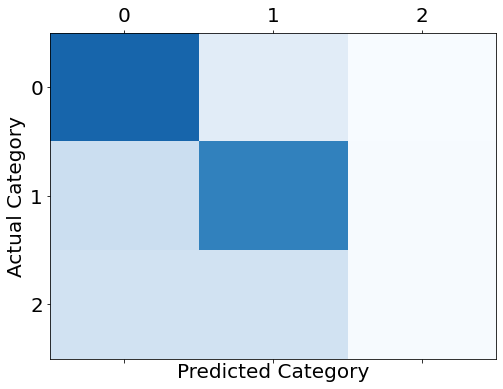

```python
present_accuracy(model3, test_iter,classes=3);
```

Here we can see the final accuracy, alongside with the confusion matrix

The model is slightly overfitting, as the trainin accuracy is higher then the test accuracy.  
Alongside with that, the confusion matrix show us that the neutral class have the most mistakes, while for positive and negative the model is pretty accurate, it does not know how to classify the neutral examples.  
This phenomenan is familiar and make sence for two reasons. First, even for human being it is hard to say when something is nither good of bad.  
Second, the number of the neutral samples is about half as the number of positive and negative, and it's usually happen with imbalanced data.

to support this claim, we provide some more statistics below, alongside with Precision, Recall and F1 score and show that the F1 for neutral is extreamly low compare to the rest of the model accuracy.

```python
print_stats(model3, test_iter,classes=3)
```

```
              precision    recall  f1-score   support

           0      0.658     0.872     0.750       909
           1      0.693     0.753     0.722       912
           2      0.385     0.013     0.025       389

    accuracy                          0.672      2210
   macro avg      0.578     0.546     0.499      2210
weighted avg      0.624     0.672     0.611      2210
```

One might change the loss function to optimize over F1 or over the neutral class if it's important. Since we train a model with no 'real-life' perpuse, we optimize only to achive better accuracy and leave the other options open for other work.

## Training on SST-5:

We will now train the same model on the fine grained SST to see how it performs on a more difficult task

```python
checkpoint = ''#'project/Models/SST5_RNN_'
optimizer = torch.optim.Adam(model5.parameters(), lr=learning_rate[0])
checkpoint_file_final = f'{checkpoint}.pt'
if os.path.isfile(checkpoint_file_final):
    print(f'*** Loading final checkpoint file {checkpoint_file_final} (not training)')
    saved_state = torch.load(checkpoint_file_final, map_location=device)
    model5.load_state_dict(saved_state['model_state'])
else:
    try:
        train_accur_base_5, valid_accur_base_5,train_losses_base_5,valid_losses_base_5 = train_and_eval(model5,train_iter_5, valid_iter_5, optimizer, loss_fn=loss_fn, epochs=EPOCHS,name='RNN_',data_name = 'SST5')
    except KeyboardInterrupt as e:
        print('\n *** Training interrupted by user')
```

```
Epoch #0,train loss=1.580,train accuracy=0.262, validation accuracy=0.282, elapsed=2.9 sec
*** Saved checkpoint project/Models/SST5_RNN_.pt at epoch 1
Epoch #1,train loss=1.578,train accuracy=0.266, validation accuracy=0.319, elapsed=2.8 sec
*** Saved checkpoint project/Models/SST5_RNN_.pt at epoch 2
Epoch #2,train loss=1.454,train accuracy=0.342, validation accuracy=0.392, elapsed=2.8 sec
*** Saved checkpoint project/Models/SST5_RNN_.pt at epoch 3
Epoch #3,train loss=1.365,train accuracy=0.389, validation accuracy=0.404, elapsed=2.8 sec
*** Saved checkpoint project/Models/SST5_RNN_.pt at epoch 4
Epoch #4,train loss=1.329,train accuracy=0.402, validation accuracy=0.422, elapsed=2.8 sec
*** Saved checkpoint project/Models/SST5_RNN_.pt at epoch 5
Epoch #5,train loss=1.287,train accuracy=0.420, validation accuracy=0.417, elapsed=2.9 sec
Epoch #6,train loss=1.247,train accuracy=0.438, validation accuracy=0.435, elapsed=2.8 sec
*** Saved checkpoint project/Models/SST5_RNN_.pt at epoch 7
Epoch #7,train loss=1.199,train accuracy=0.469, validation accuracy=0.444, elapsed=2.9 sec
*** Saved checkpoint project/Models/SST5_RNN_.pt at epoch 8
Epoch #8,train loss=1.154,train accuracy=0.487, validation accuracy=0.423, elapsed=2.8 sec
Epoch #9,train loss=1.115,train accuracy=0.511, validation accuracy=0.433, elapsed=2.8 sec
Epoch #10,train loss=1.056,train accuracy=0.530, validation accuracy=0.424, elapsed=2.8 sec
Epoch #11,train loss=1.019,train accuracy=0.557, validation accuracy=0.421, elapsed=2.8 sec
Epoch #12,train loss=0.977,train accuracy=0.581, validation accuracy=0.426, elapsed=2.9 sec
Epoch #13,train loss=0.921,train accuracy=0.610, validation accuracy=0.439, elapsed=2.8 sec
Epoch #14,train loss=0.887,train accuracy=0.633, validation accuracy=0.433, elapsed=2.8 sec
Epoch #15,train loss=0.849,train accuracy=0.656, validation accuracy=0.426, elapsed=2.9 sec
Epoch #16,train loss=0.821,train accuracy=0.667, validation accuracy=0.421, elapsed=2.8 sec
Epoch #17,train loss=0.777,train accuracy=0.687, validation accuracy=0.421, elapsed=2.8 sec
Epoch #18,train loss=0.753,train accuracy=0.697, validation accuracy=0.407, elapsed=2.8 sec
Epoch #19,train loss=0.730,train accuracy=0.707, validation accuracy=0.405, elapsed=2.8 sec
```

```
Test accuracy: 44.977%
```

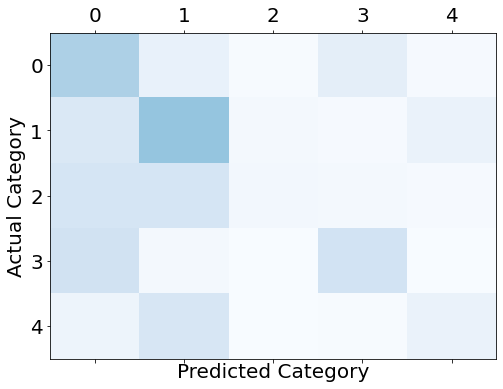

```
44.97737556561086
```

```python
present_accuracy(model5, test_iter_5,classes=5)
```

Here we show the accuracy and confusion matrix as before.

This is a much harder problem to solve, as we can see from the confusion matrix, the model is the most certain about the positive and negative classes.

We would also show the same statistical attributes as before

```python
print_stats(model5, valid_accur_5,classes=5)
```

[output not shown]

## Self Attention Model

We've tried to overcome this results by using a self attention mechanisem.

In this work we've implemented both the given paper self attention and a sligthly newer version that we've found that work better for the given problem.

This model has an attention layer, ontop of the GRU baed rnn, so the representation of each token hidden state is multiply with the Attention head (that in turn, get the rnn output as an input for the Query, Key and Value, thus the name self attention).

The first implementation based on "Self-Attention-Based BiLSTM Model for Short Text Fine-Grained Sentiment Classification" of xie et el since it achive better results  
.

ilustration:

[figure not shown]

```python
attnModel = AttentionAnalyzer(VOC_DIM, EMBEDDING_DIM, HIDDEN_DIM*2, OUTPUT_DIM[0], word_embeddings, layers=NUM_LAYERS,dropout=0.4).to(device) #attention model for SST3
print(f'The Attention model for 3-classes has {count_parameters(attnModel):,} trainable weights')
```

```
The Attention model for 3-classes has 68,548 trainable weights
```

*Training the model with attention for SST-3*

```python
optimizer = torch.optim.Adam(attnModel.parameters(), lr=learning_rate[0])
loss_fn = nn.NLLLoss()
# Train, unless final checkpoint is found
checkpoint_attn = ''#'project/Models/SST3_Attention_'
checkpoint_file_final = f'{checkpoint_attn}.pt'
if os.path.isfile(checkpoint_file_final):
    print(f'*** Loading final checkpoint file {checkpoint_file_final} (not training)')
    saved_state = torch.load(checkpoint_file_final, map_location=device)
    attnModel.load_state_dict(saved_state['model_state'])
else:
    try:
        train_accur_attn_3, valid_accur_attn_3,train_losses_attn_3,valid_losses_attn_3=\
        train_and_eval(attnModel,train_iter, valid_iter, optimizer, loss_fn=loss_fn, epochs=EPOCHS,name='Attention_',data_name = 'SST3')

    except KeyboardInterrupt as e:
        print('\n *** Training interrupted by user')
```

```
Epoch #0,train loss=0.982,train accuracy=0.510, validation accuracy=0.653, elapsed=2.0 sec
*** Saved checkpoint project/Models/SST3_Attention_.pt at epoch 1
Epoch #1,train loss=0.869,train accuracy=0.584, validation accuracy=0.677, elapsed=2.0 sec
*** Saved checkpoint project/Models/SST3_Attention_.pt at epoch 2
Epoch #2,train loss=0.832,train accuracy=0.608, validation accuracy=0.671, elapsed=2.0 sec
Epoch #3,train loss=0.795,train accuracy=0.622, validation accuracy=0.688, elapsed=2.1 sec
*** Saved checkpoint project/Models/SST3_Attention_.pt at epoch 4
Epoch #4,train loss=0.771,train accuracy=0.640, validation accuracy=0.670, elapsed=2.1 sec
Epoch #5,train loss=0.729,train accuracy=0.653, validation accuracy=0.668, elapsed=2.0 sec
Epoch #6,train loss=0.697,train accuracy=0.666, validation accuracy=0.648, elapsed=1.9 sec
Epoch #7,train loss=0.656,train accuracy=0.686, validation accuracy=0.645, elapsed=2.1 sec
Epoch #8,train loss=0.626,train accuracy=0.694, validation accuracy=0.640, elapsed=2.2 sec
Epoch #9,train loss=0.592,train accuracy=0.712, validation accuracy=0.658, elapsed=2.2 sec
Epoch #10,train loss=0.547,train accuracy=0.730, validation accuracy=0.625, elapsed=1.9 sec
Epoch #11,train loss=0.515,train accuracy=0.748, validation accuracy=0.625, elapsed=2.0 sec
Epoch #12,train loss=0.488,train accuracy=0.764, validation accuracy=0.640, elapsed=2.2 sec
Epoch #13,train loss=0.464,train accuracy=0.769, validation accuracy=0.625, elapsed=2.0 sec
Epoch #14,train loss=0.434,train accuracy=0.783, validation accuracy=0.633, elapsed=2.1 sec
Epoch #15,train loss=0.407,train accuracy=0.796, validation accuracy=0.627, elapsed=1.9 sec
Epoch #16,train loss=0.389,train accuracy=0.803, validation accuracy=0.620, elapsed=2.0 sec
Epoch #17,train loss=0.365,train accuracy=0.809, validation accuracy=0.634, elapsed=2.0 sec
Epoch #18,train loss=0.346,train accuracy=0.818, validation accuracy=0.634, elapsed=2.0 sec
Epoch #19,train loss=0.344,train accuracy=0.822, validation accuracy=0.633, elapsed=2.0 sec
```

```
Test accuracy: 69.774%
```

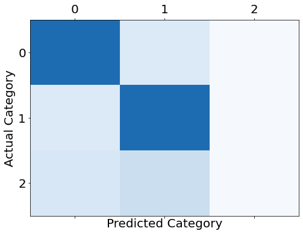

```
              precision    recall  f1-score   support

           0      0.725     0.845     0.780       909
           1      0.681     0.840     0.752       912
           2      0.308     0.021     0.039       389

    accuracy                          0.698      2210
   macro avg      0.571     0.568     0.524      2210
weighted avg      0.633     0.698     0.638      2210
```

```python
present_accuracy(attnModel, test_iter,classes=3)
print_stats(attnModel, test_iter,classes=3)
```

As we can see, this model still strugle with the neutral class, but achive better results in about 2-3 %

```python
attnModel5 = AttentionAnalyzer(VOC_DIM,EMBEDDING_DIM,HIDDEN_DIM*4,OUTPUT_DIM[1],word_embeddings_5,layers=2*NUM_LAYERS,dropout=0.3).to(device)#attention model for SST5
print(f"Attention model:{attnModel5}")
print(f'The Attention model for 5-classes has {count_parameters(attnModel5):,} trainable weights')
```

```
Attention model:AttentionAnalyzer(
  (embd): Embedding(15482, 300)
  (rnn): GRU(300, 64, num_layers=2, dropout=0.3, bidirectional=True)
  (W_s1): Linear(in_features=128, out_features=128, bias=True)
  (AttnDrop): Dropout(p=0.3, inplace=False)
  (W_s2): Linear(in_features=128, out_features=1, bias=True)
  (sentiment): Linear(in_features=128, out_features=5, bias=True)
  (DO): Dropout(p=0.3, inplace=False)
  (log_softmax): LogSoftmax(dim=1)
)
The Attention model for 5-classes has 232,326 trainable weights
```

*Training the attention model for STT-5*

```python
checkpoint_attn ='project/Models/SST5_Attention_'
optimizer = torch.optim.Adam(attnModel5.parameters(), lr=learning_rate[1])
# Train, unless final checkpoint is found
checkpoint_file_final = f'{checkpoint_attn}.pt'
if os.path.isfile(checkpoint_file_final):
    print(f'*** Loading final checkpoint file {checkpoint_file_final} (not training)')
    saved_state = torch.load(checkpoint_file_final, map_location=device)
    attnModel5.load_state_dict(saved_state['model_state'])
else:
    try:
        train_accur_attn_5, valid_accur_attn_5,train_losses_attn_5,valid_losses_attn_5=\
        train_and_eval(attnModel5,train_iter_5, valid_iter_5, optimizer, loss_fn=loss_fn, epochs=EPOCHS,name='Attention_',data_name = 'SST5')

    except KeyboardInterrupt as e:
        print('\n *** Training interrupted by user')
```

```
Epoch #0,train loss=1.578,train accuracy=0.268, validation accuracy=0.336, elapsed=3.3 sec
*** Saved checkpoint project/Models/SST5_Attention_.pt at epoch 1
Epoch #1,train loss=1.520,train accuracy=0.319, validation accuracy=0.368, elapsed=3.5 sec
*** Saved checkpoint project/Models/SST5_Attention_.pt at epoch 2
Epoch #2,train loss=1.426,train accuracy=0.369, validation accuracy=0.413, elapsed=4.2 sec
*** Saved checkpoint project/Models/SST5_Attention_.pt at epoch 3
Epoch #3,train loss=1.388,train accuracy=0.381, validation accuracy=0.419, elapsed=4.2 sec
*** Saved checkpoint project/Models/SST5_Attention_.pt at epoch 4
Epoch #4,train loss=1.365,train accuracy=0.401, validation accuracy=0.434, elapsed=4.3 sec
*** Saved checkpoint project/Models/SST5_Attention_.pt at epoch 5
Epoch #5,train loss=1.355,train accuracy=0.400, validation accuracy=0.438, elapsed=4.3 sec
*** Saved checkpoint project/Models/SST5_Attention_.pt at epoch 6
Epoch #6,train loss=1.335,train accuracy=0.407, validation accuracy=0.424, elapsed=4.3 sec
Epoch #7,train loss=1.324,train accuracy=0.417, validation accuracy=0.442, elapsed=4.3 sec
*** Saved checkpoint project/Models/SST5_Attention_.pt at epoch 8
Epoch #8,train loss=1.315,train accuracy=0.417, validation accuracy=0.440, elapsed=4.3 sec
Epoch #9,train loss=1.304,train accuracy=0.425, validation accuracy=0.447, elapsed=4.3 sec
*** Saved checkpoint project/Models/SST5_Attention_.pt at epoch 10
Epoch #10,train loss=1.299,train accuracy=0.418, validation accuracy=0.461, elapsed=4.3 sec
*** Saved checkpoint project/Models/SST5_Attention_.pt at epoch 11
Epoch #11,train loss=1.284,train accuracy=0.435, validation accuracy=0.450, elapsed=4.3 sec
Epoch #12,train loss=1.276,train accuracy=0.442, validation accuracy=0.460, elapsed=4.3 sec
Epoch #13,train loss=1.270,train accuracy=0.443, validation accuracy=0.465, elapsed=4.3 sec
*** Saved checkpoint project/Models/SST5_Attention_.pt at epoch 14
Epoch #14,train loss=1.268,train accuracy=0.442, validation accuracy=0.458, elapsed=4.3 sec
Epoch #15,train loss=1.254,train accuracy=0.444, validation accuracy=0.451, elapsed=4.3 sec
Epoch #16,train loss=1.245,train accuracy=0.448, validation accuracy=0.458, elapsed=4.3 sec
Epoch #17,train loss=1.244,train accuracy=0.449, validation accuracy=0.463, elapsed=4.2 sec
Epoch #18,train loss=1.227,train accuracy=0.461, validation accuracy=0.454, elapsed=4.3 sec
Epoch #19,train loss=1.232,train accuracy=0.461, validation accuracy=0.464, elapsed=4.2 sec
```

```
Test accuracy: 47.149%
```

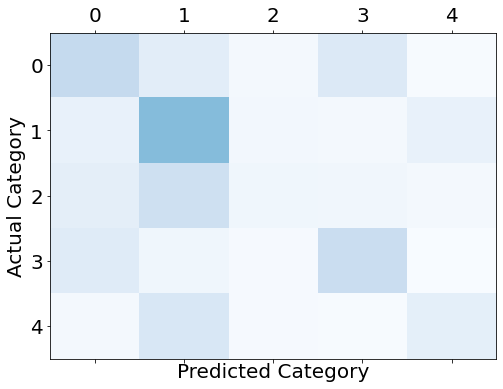

```
              precision    recall  f1-score   support

           0    0.44484   0.49020   0.46642       510
           1    0.46581   0.68878   0.55577       633
           2    0.36634   0.09512   0.15102       389
           3    0.54524   0.57393   0.55922       399
           4    0.47120   0.32258   0.38298       279

    accuracy                        0.47149      2210
   macro avg    0.45869   0.43412   0.42308      2210
weighted avg    0.45848   0.47149   0.44272      2210
```

```python
present_accuracy(attnModel5, test_iter_5,classes=5)
print_stats(attnModel5, test_iter_5,classes=5)
```

## Multi Head Attention

Now we would provide a heavier model, that uses N attention heads (we chose 8) that work on the word embeding and Avg the score over them.  
This is the score of all the heads of the sentence, and then we use 2 layers of FC to reduce and make the prediction.

[figure not shown]

```
The Multy Head Attention model for 3-classes has 215,043 trainable weights
Epoch #0,train loss=0.969,train accuracy=0.528, validation accuracy=0.618, elapsed=2.2 sec
*** Saved checkpoint project/Models/SST3_MHA.pt at epoch 1
Epoch #1,train loss=0.817,train accuracy=0.648, validation accuracy=0.652, elapsed=2.2 sec
*** Saved checkpoint project/Models/SST3_MHA.pt at epoch 2
Epoch #2,train loss=0.785,train accuracy=0.664, validation accuracy=0.641, elapsed=2.4 sec
Epoch #3,train loss=0.764,train accuracy=0.671, validation accuracy=0.665, elapsed=2.7 sec
*** Saved checkpoint project/Models/SST3_MHA.pt at epoch 4
Epoch #4,train loss=0.743,train accuracy=0.682, validation accuracy=0.643, elapsed=2.7 sec
Epoch #5,train loss=0.724,train accuracy=0.691, validation accuracy=0.648, elapsed=2.7 sec
Epoch #6,train loss=0.703,train accuracy=0.697, validation accuracy=0.651, elapsed=2.8 sec
Epoch #7,train loss=0.677,train accuracy=0.710, validation accuracy=0.646, elapsed=2.7 sec
Epoch #8,train loss=0.651,train accuracy=0.718, validation accuracy=0.651, elapsed=2.7 sec
Epoch #9,train loss=0.624,train accuracy=0.732, validation accuracy=0.649, elapsed=2.8 sec
Epoch #10,train loss=0.600,train accuracy=0.742, validation accuracy=0.640, elapsed=2.7 sec
Epoch #11,train loss=0.571,train accuracy=0.755, validation accuracy=0.627, elapsed=2.7 sec
Epoch #12,train loss=0.539,train accuracy=0.768, validation accuracy=0.625, elapsed=2.7 sec
Epoch #13,train loss=0.517,train accuracy=0.774, validation accuracy=0.639, elapsed=2.7 sec
Epoch #14,train loss=0.485,train accuracy=0.793, validation accuracy=0.635, elapsed=2.7 sec
Epoch #15,train loss=0.448,train accuracy=0.808, validation accuracy=0.635, elapsed=2.7 sec
Epoch #16,train loss=0.429,train accuracy=0.814, validation accuracy=0.584, elapsed=2.8 sec
Epoch #17,train loss=0.405,train accuracy=0.831, validation accuracy=0.577, elapsed=2.7 sec
Epoch #18,train loss=0.373,train accuracy=0.844, validation accuracy=0.600, elapsed=2.8 sec
Epoch #19,train loss=0.346,train accuracy=0.854, validation accuracy=0.605, elapsed=2.7 sec
Test accuracy: 67.376%
```

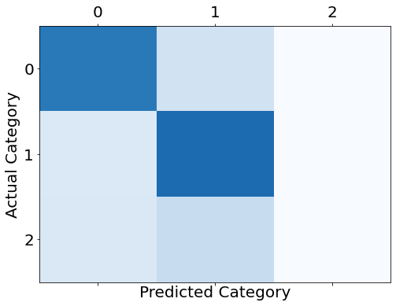

```
              precision    recall  f1-score   support

           0      0.713     0.788     0.749       909
           1      0.641     0.846     0.729       912
           2      1.000     0.003     0.005       389

    accuracy                          0.674      2210
   macro avg      0.785     0.546     0.494      2210
weighted avg      0.734     0.674     0.610      2210
```

```python
MHA = MHAA(VOC_DIM, EMBEDDING_DIM, HIDDEN_DIM*4, OUTPUT_DIM[0], word_embeddings, layers=NUM_LAYERS,dropout=0.4).to(device) #attention model for SST3
print(f'The Multy Head Attention model for 3-classes has {count_parameters(MHA):,} trainable weights')
optimizer = torch.optim.Adam(MHA.parameters(), lr=learning_rate[0])
loss_fn = nn.NLLLoss()
train_accur_3, valid_accur_3,train_losses_3,valid_losses_3 = train_and_eval(MHA,train_iter, valid_iter, optimizer, loss_fn=loss_fn, epochs=EPOCHS,name='MHA',data_name = 'SST3');
present_accuracy(MHA, test_iter,classes=3)
print_stats(MHA, test_iter,classes=3)
```

```
The Multy Head Attention model for 5-classes has 215,043 trainable weights
Epoch #0,train loss=1.575,train accuracy=0.268, validation accuracy=0.338, elapsed=4.2 sec
*** Saved checkpoint project/Models/SST5_MHA.pt at epoch 1
Epoch #1,train loss=1.428,train accuracy=0.369, validation accuracy=0.392, elapsed=4.3 sec
*** Saved checkpoint project/Models/SST5_MHA.pt at epoch 2
Epoch #2,train loss=1.316,train accuracy=0.422, validation accuracy=0.376, elapsed=4.2 sec
Epoch #3,train loss=1.284,train accuracy=0.436, validation accuracy=0.364, elapsed=4.2 sec
Epoch #4,train loss=1.253,train accuracy=0.451, validation accuracy=0.403, elapsed=4.2 sec
*** Saved checkpoint project/Models/SST5_MHA.pt at epoch 5
Epoch #5,train loss=1.238,train accuracy=0.447, validation accuracy=0.436, elapsed=4.2 sec
*** Saved checkpoint project/Models/SST5_MHA.pt at epoch 6
Epoch #6,train loss=1.216,train accuracy=0.460, validation accuracy=0.426, elapsed=4.2 sec
Epoch #7,train loss=1.208,train accuracy=0.469, validation accuracy=0.454, elapsed=4.2 sec
*** Saved checkpoint project/Models/SST5_MHA.pt at epoch 8
Epoch #8,train loss=1.183,train accuracy=0.479, validation accuracy=0.415, elapsed=4.2 sec
Epoch #9,train loss=1.170,train accuracy=0.482, validation accuracy=0.439, elapsed=4.2 sec
Epoch #10,train loss=1.153,train accuracy=0.502, validation accuracy=0.420, elapsed=4.2 sec
Epoch #11,train loss=1.141,train accuracy=0.500, validation accuracy=0.385, elapsed=4.2 sec
Epoch #12,train loss=1.132,train accuracy=0.501, validation accuracy=0.445, elapsed=4.2 sec
Epoch #13,train loss=1.108,train accuracy=0.519, validation accuracy=0.424, elapsed=4.2 sec
Epoch #14,train loss=1.108,train accuracy=0.517, validation accuracy=0.443, elapsed=4.2 sec
Epoch #15,train loss=1.093,train accuracy=0.519, validation accuracy=0.422, elapsed=4.2 sec
Epoch #16,train loss=1.073,train accuracy=0.528, validation accuracy=0.445, elapsed=4.2 sec
Epoch #17,train loss=1.063,train accuracy=0.535, validation accuracy=0.426, elapsed=4.2 sec
Epoch #18,train loss=1.052,train accuracy=0.539, validation accuracy=0.430, elapsed=4.2 sec
Epoch #19,train loss=1.026,train accuracy=0.549, validation accuracy=0.413, elapsed=4.2 sec
Test accuracy: 45.973%
```

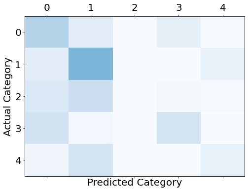

```
              precision    recall  f1-score   support

           0    0.39640   0.60392   0.47863       510
           1    0.46224   0.72512   0.56458       633
           2    1.00000   0.00514   0.01023       389
           3    0.62681   0.43358   0.51259       399
           4    0.45679   0.26523   0.33560       279

    accuracy                        0.45973      2210
   macro avg    0.58845   0.40660   0.38033      2210
weighted avg    0.57072   0.45973   0.40888      2210
```

```python
MHA5 = MHAA(VOC_DIM, EMBEDDING_DIM, HIDDEN_DIM*4, OUTPUT_DIM[1], word_embeddings, layers=NUM_LAYERS*2,dropout=0.4).to(device) #attention model for SST3
print(f'The Multy Head Attention model for 5-classes has {count_parameters(MHA):,} trainable weights')
optimizer = torch.optim.Adam(MHA5.parameters(), lr=learning_rate[0])
loss_fn = nn.NLLLoss()
train_accur_5, valid_accur_5,train_losses_5,valid_losses_5 = train_and_eval(MHA5,train_iter_5, valid_iter_5, optimizer, loss_fn=loss_fn, epochs=EPOCHS,name='MHA',data_name = 'SST5');
present_accuracy(MHA5, test_iter_5,classes=5)
print_stats(MHA5, test_iter_5,classes=5)
```

## Comparing the different models

Now, we would present a comparison of the different models by the diffirent loss and accuracy over the train and test data.

```python
def plot_results(results): #results- list of results from different models, each result is a list
    fig,_ = plt.subplots(nrows=2,ncols=2,sharex=True, figsize = (18,12))
    epochs = [i for i in range(EPOCHS)]
    for i, plot_type in enumerate(('train_acc', 'train_loss', 'valid_acc', 'valid_loss')):
        ax = fig.axes[i]
        models_res = results[plot_type]
        for model in models_res.keys():
            ax.plot(np.array(epochs), models_res[model], label=model)
        ax.set_title(plot_type)
        ax.set_xlabel('epoch')
        ax.legend()
    return fig
```

## SST-3 Comparison

First, we will compare the performance of different models on SST-3 dataset.

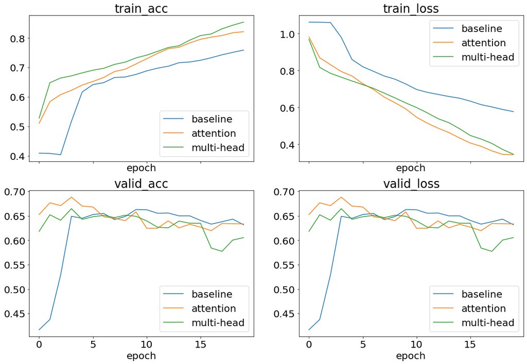

```python
results_3 = {'train_acc':None,'valid_acc':None,'train_loss':None,'valid_loss':None}
results_3['train_acc'] = {'baseline':train_accur_base_3,'attention':train_accur_attn_3,'multi-head':train_accur_3}
results_3['valid_acc'] = {'baseline':valid_accur_base_3,'attention':valid_accur_attn_3,'multi-head':valid_accur_3}
results_3['train_loss'] = {'baseline':train_losses_base_3,'attention':train_losses_attn_3,'multi-head':train_losses_3}
results_3['valid_loss'] = {'baseline':valid_losses_base_3,'attention':valid_losses_attn_3,'multi-head':valid_losses_3}

plot_results(results_3);
```

First, and foremost, we can see that the attention models (both of the papers implementations) achive better results then the baseline GRU based RNN on the test set.  
the train loss graph shows a good decline, as a loss graph during optimization process should look like.  
note 1: The validation loss graph is mostly for sainity check for us, that there is no data leakage from the train to the validation set and we do not optimize over it.  
note 2: The last validation accuracy is not the highest exist during the training process, we implemented a feature that save the model with most validation accuracy during training.

## SST-5 (Fine Grained) Comparison

Now, we will compare the performance of these models on SST-5

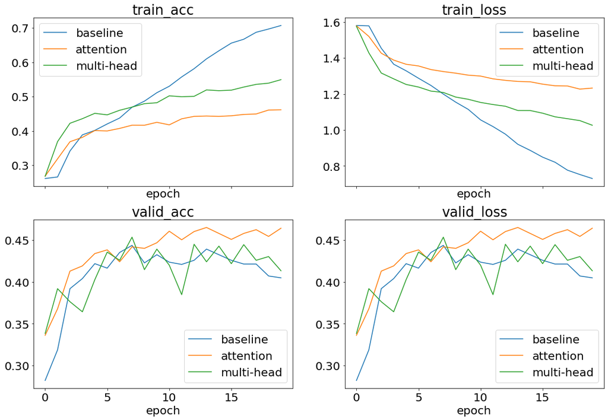

```python
results_5 = {'train_acc':None,'valid_acc':None,'train_loss':None,'valid_loss':None}

results_5['train_acc'] = {'baseline':train_accur_base_5,'attention':train_accur_attn_5,'multi-head':train_accur_5}
results_5['valid_acc'] = {'baseline':valid_accur_base_5,'attention':valid_accur_attn_5,'multi-head':valid_accur_5}
results_5['train_loss'] = {'baseline':train_losses_base_5,'attention':train_losses_attn_5,'multi-head':train_losses_5}
results_5['valid_loss'] = {'baseline':valid_losses_base_5,'attention':valid_losses_attn_5,'multi-head':valid_losses_5}
plot_results(results_5);
```

Again, we could see that the attention models achieved better accuracy than the baseline model.  
The problem of sentiment analyisis with 5 classes is considered to be hard, therefore the hyper-parameter search made us choose an overfitting model for the baseline architecture.  
note 1: The validation loss graph is mostly for sainity check for us, that there is no data leakage from the train to the validation set and we do not optimize over it.  
note 2: The last validation accuracy is not the highest exist during the training process, we implemented a feature that save the model with most validation accuracy during training.  
note 3: To avoid over fitting for this dataset, we used strong explicit regularization of dropout.

**Tuning Hyper-Parameters**  
In this notebook we will find the optimal hyper-parameters by training our model and checking the validation accuracy

```python
#setup
import json

import os
import sys
import time
import torch
import matplotlib.pyplot as plt
import warnings
import torch.nn as nn
from IPython.display import Markdown, display

warnings.simplefilter("ignore")
plt.rcParams['font.size'] = 20
data_dir = os.path.expanduser('~/.pytorch-datasets')
device = torch.device('cuda' if torch.cuda.is_available() else 'cpu')
print(device)

#loading our models
from project.Trainer import train_and_eval
from project.RNN import SentimentAnalyzer
from project.Attention import AttentionAnalyzer

#loading the dataset
import torchtext.data
from torchtext.vocab import Vectors, GloVe

review_parser = torchtext.data.Field(
    sequential=True, use_vocab=True, lower=True,
    init_token='<sos>', eos_token='<eos>', dtype=torch.long,
    tokenize='spacy', tokenizer_language='en_core_web_sm'
)

# This Field object converts the text labels into numeric values (0,1,2)
label_parser = torchtext.data.Field(
    is_target=True, sequential=False, unk_token=None, use_vocab=True
)
import torchtext.datasets

ds_train, ds_valid, ds_test = torchtext.datasets.SST.splits(
    review_parser, label_parser, root=data_dir,fine_grained=True #was changed from false for SST-5
)
#building vocabulary and loading GloVe 6B pretrained embeddings
review_parser.build_vocab(ds_train,vectors=GloVe(name='6B', dim=300))
label_parser.build_vocab(ds_train)
word_embeddings = review_parser.vocab.vectors
word_embeddings = word_embeddings.to(device=device)
```

```
cuda
```

```python
def create_dataset(batch_size):
    BATCH_SIZE = batch_size #hyper parameter, could be changed

    # BucketIterator creates batches with samples of similar length
    # to minimize the number of <pad> tokens in the batch.
    dl_train, dl_valid, dl_test = torchtext.data.BucketIterator.splits(
        (ds_train, ds_valid, ds_test), batch_size=BATCH_SIZE,
        shuffle=True, device=device)

    train_iter, valid_iter, test_iter = torchtext.data.BucketIterator.splits((ds_train, ds_valid, ds_test), batch_size=BATCH_SIZE, sort_key=lambda x: len(x.text), repeat=False, shuffle=True)
    return train_iter, valid_iter, test_iter

def create_model(hidden_dim, layers):
    INPUT_DIM = len(review_parser.vocab)
    EMBEDDING_DIM = 300
    HIDDEN_DIM = hidden_dim
    OUTPUT_DIM = 5 #was 3

    model = SentimentAnalyzer(INPUT_DIM, EMBEDDING_DIM, HIDDEN_DIM, OUTPUT_DIM, word_embeddings, layers=2)
    attnModel = AttentionAnalyzer(INPUT_DIM, EMBEDDING_DIM, HIDDEN_DIM, OUTPUT_DIM, word_embeddings, layers=2)
    #model = RNN(32, 2, 256, len(review_parser.vocab), 300, word_embeddings)
    model = model.to(device)

    return model,attnModel

def training_model(lr, epochs, model, train_iter, test_iter, BATCH_SIZE, HIDDEN_DIM, layers, do):
    batch_size = BATCH_SIZE
    output_size = 3
    hidden_size = HIDDEN_DIM
    embedding_length = 300
    EPOCHS = 20
    params = {'bs':BATCH_SIZE, 'hidden_dim':HIDDEN_DIM, 'lr':lr.item(), 'layers':layers}
    if do >= 0.05:
        params['do'] = do
    #open file and check if trained, if so than return pretrained accuracy
    try:
        results = open(f"Proj_results/Fine_{json.dumps(params)}","r") #Regular for SST-3 Fine for SST-5
        data = json.loads(results.read())
        print(f"loaded from file: Fine_{json.dumps(params)}")
        return max(data["valid"])
    except: #the file does not exist i.e no model was trained with these parameters
        nop = 0



    #train and return test best accuracy and average accuracy for baseline model
    optimizer = torch.optim.Adam(model.parameters(), lr=lr)
    loss_fn = nn.NLLLoss()
    #RNN_train_loss_arr, RNN_train_acc_arr, RNN_val_loss_arr, RNN_val_acc_arr =
    _,_,train_accur, valid_accur = train_and_eval(model,train_iter, test_iter, optimizer, loss_fn=loss_fn, epochs=EPOCHS, verbose=False)

    results = open(f"Proj_results/Fine_{json.dumps(params)}", "w")
    results.write(json.dumps({'params':params, 'train':train_accur, 'valid':test_accur}))
    results.close()

    return max(valid_accur) #could check just last accuracy
```

```python
#setting the hyperparameters range
batches = [32] #batch sizes from 16 to 128
hiddens = [16,32,64] #list of possible hidden size (to model)
layers = [i for i in range(1,2 + 1)] #layers from 1 to 3 (could add more)
learning_rates = torch.logspace(-3,-4,3) #learning rates from 0.01 to 10^-6
dropouts = [0,0.3,0.5]#torch.linspace(0,0.5,4) #dropout rate from 0 to 0.5
epochs = 20#epochs will remain static

file = open("results.txt","w")
file.write("pending")
file.close()
```

```python
train_iter, valid_iter, test_iter = create_dataset(32)
'''
print(batches)
print(hiddens)
print(layers)
print(learning_rates)
'''

best_params = None
best_accur = 0
for batch in batches:
#batch size is fixed to 32 just for the moment
    for h in hiddens:
        for layer in layers:
            for drop in dropouts:
                for lr in learning_rates:
                    params =  {'bs':batch, 'hidden_dim':h, 'num_layers':layer, 'lr':lr.item(), 'dropout':drop}
                    _, attnModel = create_model(h, layer)
                    attnModel = attnModel.to(device)
                    print(f"training params:{json.dumps(params)}")
                    accur = training_model(lr, epochs, attnModel, train_iter, valid_iter, batch, h, layer, drop)
                    print(f'params:{params}, accur:{accur}')
                    if accur > best_accur:
                        display(Markdown(f'**best:{accur}**'))
                        best_accur = accur
                        best_params = params

print(best_params)
file = open("results.txt","w")
file.write(json.dumps(best_params))
file.close()
```

```
training params:{"bs": 32, "hidden_dim": 16, "num_layers": 1, "lr": 0.0010000000474974513, "dropout": 0}
params:{'bs': 32, 'hidden_dim': 16, 'num_layers': 1, 'lr': 0.0010000000474974513, 'dropout': 0}, accur:0.44151785714285713
```

**best:0.44151785714285713**

```
training params:{"bs": 32, "hidden_dim": 16, "num_layers": 1, "lr": 0.0003162277571391314, "dropout": 0}
params:{'bs': 32, 'hidden_dim': 16, 'num_layers': 1, 'lr': 0.0003162277571391314, 'dropout': 0}, accur:0.43660714285714286
training params:{"bs": 32, "hidden_dim": 16, "num_layers": 1, "lr": 9.999999747378752e-05, "dropout": 0}
params:{'bs': 32, 'hidden_dim': 16, 'num_layers': 1, 'lr': 9.999999747378752e-05, 'dropout': 0}, accur:0.42723214285714284
training params:{"bs": 32, "hidden_dim": 16, "num_layers": 1, "lr": 0.0010000000474974513, "dropout": 0.3}
params:{'bs': 32, 'hidden_dim': 16, 'num_layers': 1, 'lr': 0.0010000000474974513, 'dropout': 0.3}, accur:0.44151785714285713
training params:{"bs": 32, "hidden_dim": 16, "num_layers": 1, "lr": 0.0003162277571391314, "dropout": 0.3}
params:{'bs': 32, 'hidden_dim': 16, 'num_layers': 1, 'lr': 0.0003162277571391314, 'dropout': 0.3}, accur:0.4433035714285714
```

**best:0.4433035714285714**

```
training params:{"bs": 32, "hidden_dim": 16, "num_layers": 1, "lr": 9.999999747378752e-05, "dropout": 0.3}
params:{'bs': 32, 'hidden_dim': 16, 'num_layers': 1, 'lr': 9.999999747378752e-05, 'dropout': 0.3}, accur:0.4263392857142857
training params:{"bs": 32, "hidden_dim": 16, "num_layers": 1, "lr": 0.0010000000474974513, "dropout": 0.5}
params:{'bs': 32, 'hidden_dim': 16, 'num_layers': 1, 'lr': 0.0010000000474974513, 'dropout': 0.5}, accur:0.45401785714285714
```

**best:0.45401785714285714**

```
training params:{"bs": 32, "hidden_dim": 16, "num_layers": 1, "lr": 0.0003162277571391314, "dropout": 0.5}
params:{'bs': 32, 'hidden_dim': 16, 'num_layers': 1, 'lr': 0.0003162277571391314, 'dropout': 0.5}, accur:0.45223214285714286
training params:{"bs": 32, "hidden_dim": 16, "num_layers": 1, "lr": 9.999999747378752e-05, "dropout": 0.5}
params:{'bs': 32, 'hidden_dim': 16, 'num_layers': 1, 'lr': 9.999999747378752e-05, 'dropout': 0.5}, accur:0.4419642857142857
training params:{"bs": 32, "hidden_dim": 16, "num_layers": 2, "lr": 0.0010000000474974513, "dropout": 0}
params:{'bs': 32, 'hidden_dim': 16, 'num_layers': 2, 'lr': 0.0010000000474974513, 'dropout': 0}, accur:0.44776785714285716
training params:{"bs": 32, "hidden_dim": 16, "num_layers": 2, "lr": 0.0003162277571391314, "dropout": 0}
params:{'bs': 32, 'hidden_dim': 16, 'num_layers': 2, 'lr': 0.0003162277571391314, 'dropout': 0}, accur:0.44419642857142855
training params:{"bs": 32, "hidden_dim": 16, "num_layers": 2, "lr": 9.999999747378752e-05, "dropout": 0}
params:{'bs': 32, 'hidden_dim': 16, 'num_layers': 2, 'lr': 9.999999747378752e-05, 'dropout': 0}, accur:0.42723214285714284
training params:{"bs": 32, "hidden_dim": 16, "num_layers": 2, "lr": 0.0010000000474974513, "dropout": 0.3}
params:{'bs': 32, 'hidden_dim': 16, 'num_layers': 2, 'lr': 0.0010000000474974513, 'dropout': 0.3}, accur:0.45089285714285715
training params:{"bs": 32, "hidden_dim": 16, "num_layers": 2, "lr": 0.0003162277571391314, "dropout": 0.3}
params:{'bs': 32, 'hidden_dim': 16, 'num_layers': 2, 'lr': 0.0003162277571391314, 'dropout': 0.3}, accur:0.4544642857142857
```

**best:0.4544642857142857**

```
training params:{"bs": 32, "hidden_dim": 16, "num_layers": 2, "lr": 9.999999747378752e-05, "dropout": 0.3}
params:{'bs': 32, 'hidden_dim': 16, 'num_layers': 2, 'lr': 9.999999747378752e-05, 'dropout': 0.3}, accur:0.4433035714285714
training params:{"bs": 32, "hidden_dim": 16, "num_layers": 2, "lr": 0.0010000000474974513, "dropout": 0.5}
params:{'bs': 32, 'hidden_dim': 16, 'num_layers': 2, 'lr': 0.0010000000474974513, 'dropout': 0.5}, accur:0.44419642857142855
training params:{"bs": 32, "hidden_dim": 16, "num_layers": 2, "lr": 0.0003162277571391314, "dropout": 0.5}
params:{'bs': 32, 'hidden_dim': 16, 'num_layers': 2, 'lr': 0.0003162277571391314, 'dropout': 0.5}, accur:0.43794642857142857
training params:{"bs": 32, "hidden_dim": 16, "num_layers": 2, "lr": 9.999999747378752e-05, "dropout": 0.5}
params:{'bs': 32, 'hidden_dim': 16, 'num_layers': 2, 'lr': 9.999999747378752e-05, 'dropout': 0.5}, accur:0.425
training params:{"bs": 32, "hidden_dim": 32, "num_layers": 1, "lr": 0.0010000000474974513, "dropout": 0}
params:{'bs': 32, 'hidden_dim': 32, 'num_layers': 1, 'lr': 0.0010000000474974513, 'dropout': 0}, accur:0.4558035714285714
```

**best:0.4558035714285714**

```
training params:{"bs": 32, "hidden_dim": 32, "num_layers": 1, "lr": 0.0003162277571391314, "dropout": 0}
params:{'bs': 32, 'hidden_dim': 32, 'num_layers': 1, 'lr': 0.0003162277571391314, 'dropout': 0}, accur:0.44910714285714287
training params:{"bs": 32, "hidden_dim": 32, "num_layers": 1, "lr": 9.999999747378752e-05, "dropout": 0}
params:{'bs': 32, 'hidden_dim': 32, 'num_layers': 1, 'lr': 9.999999747378752e-05, 'dropout': 0}, accur:0.45401785714285714
training params:{"bs": 32, "hidden_dim": 32, "num_layers": 1, "lr": 0.0010000000474974513, "dropout": 0.3}
params:{'bs': 32, 'hidden_dim': 32, 'num_layers': 1, 'lr': 0.0010000000474974513, 'dropout': 0.3}, accur:0.45401785714285714
training params:{"bs": 32, "hidden_dim": 32, "num_layers": 1, "lr": 0.0003162277571391314, "dropout": 0.3}
params:{'bs': 32, 'hidden_dim': 32, 'num_layers': 1, 'lr': 0.0003162277571391314, 'dropout': 0.3}, accur:0.4517857142857143
training params:{"bs": 32, "hidden_dim": 32, "num_layers": 1, "lr": 9.999999747378752e-05, "dropout": 0.3}
params:{'bs': 32, 'hidden_dim': 32, 'num_layers': 1, 'lr': 9.999999747378752e-05, 'dropout': 0.3}, accur:0.4473214285714286
training params:{"bs": 32, "hidden_dim": 32, "num_layers": 1, "lr": 0.0010000000474974513, "dropout": 0.5}
params:{'bs': 32, 'hidden_dim': 32, 'num_layers': 1, 'lr': 0.0010000000474974513, 'dropout': 0.5}, accur:0.4450892857142857
training params:{"bs": 32, "hidden_dim": 32, "num_layers": 1, "lr": 0.0003162277571391314, "dropout": 0.5}
params:{'bs': 32, 'hidden_dim': 32, 'num_layers': 1, 'lr': 0.0003162277571391314, 'dropout': 0.5}, accur:0.45669642857142856
```

**best:0.45669642857142856**

```
training params:{"bs": 32, "hidden_dim": 32, "num_layers": 1, "lr": 9.999999747378752e-05, "dropout": 0.5}
params:{'bs': 32, 'hidden_dim': 32, 'num_layers': 1, 'lr': 9.999999747378752e-05, 'dropout': 0.5}, accur:0.4459821428571429
training params:{"bs": 32, "hidden_dim": 32, "num_layers": 2, "lr": 0.0010000000474974513, "dropout": 0}
params:{'bs': 32, 'hidden_dim': 32, 'num_layers': 2, 'lr': 0.0010000000474974513, 'dropout': 0}, accur:0.4473214285714286
training params:{"bs": 32, "hidden_dim": 32, "num_layers": 2, "lr": 0.0003162277571391314, "dropout": 0}
params:{'bs': 32, 'hidden_dim': 32, 'num_layers': 2, 'lr': 0.0003162277571391314, 'dropout': 0}, accur:0.45848214285714284
```

**best:0.45848214285714284**

```
training params:{"bs": 32, "hidden_dim": 32, "num_layers": 2, "lr": 9.999999747378752e-05, "dropout": 0}
params:{'bs': 32, 'hidden_dim': 32, 'num_layers': 2, 'lr': 9.999999747378752e-05, 'dropout': 0}, accur:0.45267857142857143
training params:{"bs": 32, "hidden_dim": 32, "num_layers": 2, "lr": 0.0010000000474974513, "dropout": 0.3}
params:{'bs': 32, 'hidden_dim': 32, 'num_layers': 2, 'lr': 0.0010000000474974513, 'dropout': 0.3}, accur:0.4517857142857143
training params:{"bs": 32, "hidden_dim": 32, "num_layers": 2, "lr": 0.0003162277571391314, "dropout": 0.3}
params:{'bs': 32, 'hidden_dim': 32, 'num_layers': 2, 'lr': 0.0003162277571391314, 'dropout': 0.3}, accur:0.44285714285714284
training params:{"bs": 32, "hidden_dim": 32, "num_layers": 2, "lr": 9.999999747378752e-05, "dropout": 0.3}
params:{'bs': 32, 'hidden_dim': 32, 'num_layers': 2, 'lr': 9.999999747378752e-05, 'dropout': 0.3}, accur:0.44910714285714287
training params:{"bs": 32, "hidden_dim": 32, "num_layers": 2, "lr": 0.0010000000474974513, "dropout": 0.5}
params:{'bs': 32, 'hidden_dim': 32, 'num_layers': 2, 'lr': 0.0010000000474974513, 'dropout': 0.5}, accur:0.45848214285714284
training params:{"bs": 32, "hidden_dim": 32, "num_layers": 2, "lr": 0.0003162277571391314, "dropout": 0.5}
params:{'bs': 32, 'hidden_dim': 32, 'num_layers': 2, 'lr': 0.0003162277571391314, 'dropout': 0.5}, accur:0.45803571428571427
training params:{"bs": 32, "hidden_dim": 32, "num_layers": 2, "lr": 9.999999747378752e-05, "dropout": 0.5}
params:{'bs': 32, 'hidden_dim': 32, 'num_layers': 2, 'lr': 9.999999747378752e-05, 'dropout': 0.5}, accur:0.44642857142857145
training params:{"bs": 32, "hidden_dim": 64, "num_layers": 1, "lr": 0.0010000000474974513, "dropout": 0}
params:{'bs': 32, 'hidden_dim': 64, 'num_layers': 1, 'lr': 0.0010000000474974513, 'dropout': 0}, accur:0.4549107142857143
training params:{"bs": 32, "hidden_dim": 64, "num_layers": 1, "lr": 0.0003162277571391314, "dropout": 0}
params:{'bs': 32, 'hidden_dim': 64, 'num_layers': 1, 'lr': 0.0003162277571391314, 'dropout': 0}, accur:0.45669642857142856
training params:{"bs": 32, "hidden_dim": 64, "num_layers": 1, "lr": 9.999999747378752e-05, "dropout": 0}
params:{'bs': 32, 'hidden_dim': 64, 'num_layers': 1, 'lr': 9.999999747378752e-05, 'dropout': 0}, accur:0.4450892857142857
training params:{"bs": 32, "hidden_dim": 64, "num_layers": 1, "lr": 0.0010000000474974513, "dropout": 0.3}
params:{'bs': 32, 'hidden_dim': 64, 'num_layers': 1, 'lr': 0.0010000000474974513, 'dropout': 0.3}, accur:0.45267857142857143
training params:{"bs": 32, "hidden_dim": 64, "num_layers": 1, "lr": 0.0003162277571391314, "dropout": 0.3}
params:{'bs': 32, 'hidden_dim': 64, 'num_layers': 1, 'lr': 0.0003162277571391314, 'dropout': 0.3}, accur:0.4558035714285714
training params:{"bs": 32, "hidden_dim": 64, "num_layers": 1, "lr": 9.999999747378752e-05, "dropout": 0.3}
params:{'bs': 32, 'hidden_dim': 64, 'num_layers': 1, 'lr': 9.999999747378752e-05, 'dropout': 0.3}, accur:0.4504464285714286
training params:{"bs": 32, "hidden_dim": 64, "num_layers": 1, "lr": 0.0010000000474974513, "dropout": 0.5}
params:{'bs': 32, 'hidden_dim': 64, 'num_layers': 1, 'lr': 0.0010000000474974513, 'dropout': 0.5}, accur:0.453125
training params:{"bs": 32, "hidden_dim": 64, "num_layers": 1, "lr": 0.0003162277571391314, "dropout": 0.5}
params:{'bs': 32, 'hidden_dim': 64, 'num_layers': 1, 'lr': 0.0003162277571391314, 'dropout': 0.5}, accur:0.45357142857142857
training params:{"bs": 32, "hidden_dim": 64, "num_layers": 1, "lr": 9.999999747378752e-05, "dropout": 0.5}
params:{'bs': 32, 'hidden_dim': 64, 'num_layers': 1, 'lr': 9.999999747378752e-05, 'dropout': 0.5}, accur:0.44821428571428573
training params:{"bs": 32, "hidden_dim": 64, "num_layers": 2, "lr": 0.0010000000474974513, "dropout": 0}
params:{'bs': 32, 'hidden_dim': 64, 'num_layers': 2, 'lr': 0.0010000000474974513, 'dropout': 0}, accur:0.4558035714285714
training params:{"bs": 32, "hidden_dim": 64, "num_layers": 2, "lr": 0.0003162277571391314, "dropout": 0}
params:{'bs': 32, 'hidden_dim': 64, 'num_layers': 2, 'lr': 0.0003162277571391314, 'dropout': 0}, accur:0.45401785714285714
training params:{"bs": 32, "hidden_dim": 64, "num_layers": 2, "lr": 9.999999747378752e-05, "dropout": 0}
params:{'bs': 32, 'hidden_dim': 64, 'num_layers': 2, 'lr': 9.999999747378752e-05, 'dropout': 0}, accur:0.45357142857142857
training params:{"bs": 32, "hidden_dim": 64, "num_layers": 2, "lr": 0.0010000000474974513, "dropout": 0.3}
params:{'bs': 32, 'hidden_dim': 64, 'num_layers': 2, 'lr': 0.0010000000474974513, 'dropout': 0.3}, accur:0.44910714285714287
training params:{"bs": 32, "hidden_dim": 64, "num_layers": 2, "lr": 0.0003162277571391314, "dropout": 0.3}
params:{'bs': 32, 'hidden_dim': 64, 'num_layers': 2, 'lr': 0.0003162277571391314, 'dropout': 0.3}, accur:0.45223214285714286
training params:{"bs": 32, "hidden_dim": 64, "num_layers": 2, "lr": 9.999999747378752e-05, "dropout": 0.3}
params:{'bs': 32, 'hidden_dim': 64, 'num_layers': 2, 'lr': 9.999999747378752e-05, 'dropout': 0.3}, accur:0.4616071428571429
```

**best:0.4616071428571429**

```
training params:{"bs": 32, "hidden_dim": 64, "num_layers": 2, "lr": 0.0010000000474974513, "dropout": 0.5}
params:{'bs': 32, 'hidden_dim': 64, 'num_layers': 2, 'lr': 0.0010000000474974513, 'dropout': 0.5}, accur:0.4616071428571429
training params:{"bs": 32, "hidden_dim": 64, "num_layers": 2, "lr": 0.0003162277571391314, "dropout": 0.5}
params:{'bs': 32, 'hidden_dim': 64, 'num_layers': 2, 'lr': 0.0003162277571391314, 'dropout': 0.5}, accur:0.44642857142857145
training params:{"bs": 32, "hidden_dim": 64, "num_layers": 2, "lr": 9.999999747378752e-05, "dropout": 0.5}
params:{'bs': 32, 'hidden_dim': 64, 'num_layers': 2, 'lr': 9.999999747378752e-05, 'dropout': 0.5}, accur:0.440625
{'bs': 32, 'hidden_dim': 64, 'num_layers': 2, 'lr': 9.999999747378752e-05, 'dropout': 0.3}
```